# Simulation Studies Based on ACTG175: Binary Endpoint (GLM)

- Show All Code
- Hide All Code
- View Source

Benefit Subgroup Identification with CD4 Response at 20 Weeks – Raw Continuous Covariates

Author

Larry F. León

Published

April 19, 2026

# 1 Introduction

## 1.1 Motivation

This document extends the ACTG175 benefit-search simulation framework from survival outcomes (time-to-event) to a **binary endpoint**: whether a patient’s CD4 count improved from baseline to 20 weeks, defined as $Y = I(\text{cd420} > \text{cd40})$.

The simulation uses the `forestsearch` GLM simulation suite (`generate_glm_dgm`, `calibrate_glm_interaction`, `simulate_from_glm_dgm`) and routes through `run_simulation_analysis()` via class-based dispatch on the `"glm_dgm"` object.

## 1.2 Realistic Analysis Setting

A prior version of this simulation discretised every continuous covariate into a binary factor **before** handing the data to `forestsearch()` / `grf.subg.harm.glm()`. The binarisation used the same cuts that define the true subgroup $Q$ (e.g. age > 34, preanti $\leq$ 744.5). That setup implicitly gives the analysis method knowledge of the true cutpoints, which is unrealistic.

The current setup **retains continuous covariates in their raw form for the analysis step**. The data-generating mechanism (DGM) is built from the discretised factors (`z1`–`z12`) because `generate_glm_dgm()` requires factor covariates and the true subgroup must be defined algebraically. The analysis methods, however, see the **raw** continuous columns (`age`, `preanti`, `wtkg`, `karnof`, `cd40`, `cd80`) along with the six truly binary indicators (`hemo`, `homo`, `drugs`, `race`, `gender`, `symptom`). Cutpoints for the continuous covariates are discovered by the search methods themselves (median splits, GRF-derived cuts, policy-tree splits), exactly as in a real analysis.

**ImportantWhat changes vs the prior (discretised) setup**

- **Ground truth is unchanged**: the true benefit subgroup $Q$ is still $\{\text{age} > 34\} \cap \{\text{preanti} \leq 744.5\}$ with prevalence $\approx 34\%$, and the DGM’s OR(Q) calibration is untouched.
- **Classification metrics are unchanged in definition**: `flag_harm` is computed identically from `z1` and `z2`.
- **What changes is the search problem**: ForestSearch must discover the cuts from candidate thresholds; GRF builds policy trees over raw continuous inputs. Expect lower sensitivity and PPV than the discretised setting, because the analyst does not receive oracle cuts.

**Cut-set coverage for this run.** ForestSearch is configured with `cut_type = "default"` (the package default), which generates four candidate cuts per continuous covariate: mean, median, Q1, and Q3. For the ACTG175 covariate distribution the median of `age` is approximately 34 and Q3 of `preanti` is approximately 744.5, so **both true Q-defining cuts happen to fall inside the default candidate set** — they are simply not privileged over the other candidates. The analyst has no oracle knowledge of which cuts matter; ForestSearch must select them based on the data. Switching to `cut_type = "median"` would exclude preanti’s Q3 cut from the candidate set entirely, providing a harder stress test. GRF policy trees search over all continuous thresholds internally and are unaffected by this setting.

## 1.3 Statistical Goals

This simulation study addresses three questions about ForestSearch and GRF standalone subgroup identification applied to **binary outcomes** in the realistic (raw covariate) setting:

1. **Detection power (H1)**: When a benefit subgroup $Q$ exists with OR(Q) = 2 (switched scale), how often do ForestSearch and GRF identify *any* subgroup?
2. **False positive control (H0)**: When the treatment effect is homogeneous (no true $Q$), how often does each method falsely declare a benefit subgroup?
3. **Classification accuracy (H1)**: Conditional on detection, how well does the estimated $\hat{Q}$ recover the true $Q$? Measured by sensitivity ($\text{sens}(\hat{Q})$: fraction of true $Q$ captured) and positive predictive value ($\text{ppv}(\hat{Q})$: fraction of $\hat{Q}$ truly in $Q$).

**TipSummary of results**

See Summary at the end for a data-driven summary of detection, classification, and timing from this run.

## 1.4 Simulation Pipeline

The simulation proceeds in six steps:

1. **Data preparation** (Section 3): Load the ACTG175 trial, restrict to arms 1 (ZDV+ddI) and 3 (ddI), switch treatment labels so ddI = `treat = 1` and ZDV+ddI = `treat = 0` (benefit search convention), and construct BOTH:
   1. the binary `z1`–`z12` factor set needed by the DGM; and
   2. the realistic analysis candidate set (`age`, `preanti`, `wtkg`, `karnof`, `cd40`, `cd80`, `hemo`, `homo`, `drugs`, `race`, `gender`, `symptom`).
2. **DGM construction** (Section 4): Fit a logistic regression to the observed data using the `z1`–`z12` factor formulation, create a 5,000-subject super-population, and define the true benefit subgroup $Q = \{z_1 = 1 \cap z_2 = 1\}$ (age > 34 AND preanti $\leq$ 744.5). The super- population retains the **raw** covariate columns as well as the `z1`–`z12` indicators.
3. **Calibration** (Section 4.2): Search over `k_inter` values to find the interaction strength that produces $\text{OR}(Q) = 2$ on the switched scale (= $0.5$ on the original scale).
4. **Single-data analysis** (Section 5): Run ForestSearch and GRF on the observed ACTG175 data using the **raw** analysis candidate set to verify the pipeline produces valid results before scaling to simulation.
5. **Monte Carlo simulation** (Section 7): For each of 100 alternative and 100 null replicates, draw a random sample of $N = 1000$ from the DGM super-population, run ForestSearch and GRF on the raw analysis covariates, and record detection, classification, and effect estimates.
6. **Evaluation** (Section 8): Compute operating characteristics (detection, sensitivity, PPV, effect estimation bias) under both hypotheses.

## 1.5 Benefit Search on the OR Scale

The benefit-search approach from Leon et al. (2024, Section 4.2) applies identically to binary outcomes, with odds ratios (OR) replacing hazard ratios (HR):

1. **Switch treatment roles**: ddI monotherapy $\to$ `treat = 1`, ZDV+ddI combination $\to$ `treat = 0`.
2. **Raise thresholds** on the OR scale: $c_1 =$ 1.667 (screening) and $c_2 =$ 1.333 (consistency). Both come from the Quarto setup chunk (`fs_or_threshold`, `fs_or_consistency`) so any change to the setup parameters flows through here automatically.
3. **Run ForestSearch** with `outcome_type = "binary"`, `effect_measure = "OR"`.
4. **Inversion** is handled automatically by the package when `subgroup_notation = "benefit"` is passed to the reporting functions.

## 1.6 Candidate Selection: `sg_focus = "maxSG"`

When several candidate subgroups simultaneously meet both the screening threshold ($c_1 =$ 1.667) and the consistency threshold ($c_2 =$ 1.333), `forestsearch()` must pick one. That choice is governed by `sg_focus`. Five options are available:

| `sg_focus` | Primary sort | Secondary | Tertiary | Interpretation |
| --- | --- | --- | --- | --- |
| `"hr"` | Pcons desc | effect desc | K asc | Package default. Favours *most-consistent* candidate. |
| `"maxSG"` | **N desc** | Pcons desc | K asc | **Largest** qualifying candidate. |
| `"minSG"` | N asc | Pcons desc | K asc | Smallest qualifying candidate. |
| `"hrMaxSG"` | N desc | effect desc | — | Compound. Forces `stop_threshold = NULL`. |
| `"hrMinSG"` | N asc | effect desc | — | Compound. Forces `stop_threshold = NULL`. |

For the ACTG175 benefit search, the analytic goal is to recover the **largest subgroup in which the ZDV+ddI combination is superior to ddI monotherapy** — the population we would, in a real trial, most want to describe and quantify. Once the screening-plus-consistency filter has passed, there is no further reason to pick a smaller, tighter subgroup; the largest qualifying candidate is the most policy-relevant one.

This choice has two practical consequences that we track throughout the operating-characteristics analysis:

1. $\widehat{|H|}$ will typically be closer to $|Q|$ than under the default `sg_focus = "hr"`, which trades size for consistency and tends to return strict subsets of $Q$.
2. The distribution of identified subgroups across simulations (reported in Section 8.2) should concentrate on a small number of definitions close to the true $Q$ anchor, rather than fragmenting into many small tight splits.

# 2 GRF Standalone: Calibration Notes

The standalone GRF analysis uses `grf.subg.harm.glm()` with `causal_forest()` for candidate variable screening and policy trees for subgroup identification. The key tuning parameter is `dmin.grf`, the minimum absolute CATE (conditional average treatment effect) on the **risk difference** scale required for a policy-tree node to be valid.

## 2.1 Configuration

For the **benefit + positive** scenario with switched treatment (the ACTG175 binary configuration), the correct GRF setup is:

- `adverse_outcome = FALSE` (Y = improvement is positive)
- Treatment indicator = **switched** (ddI = 1, ZDV+ddI = 0)
- GRF identifies the subgroup where the switched “treatment” produces the most negative CATE — i.e., where ddI monotherapy is worst relative to combination, which is the **benefit** subgroup on the original scale.

## 2.2 Impact of Raw Continuous Inputs on Calibration

Prior `dmin.grf` calibration (in `grf_dmin_calibration_binary.qmd`) was conducted on **discretised** inputs (`z1`–`z12` binary factors) and recommended `dmin.grf = 0.02` for the benefit + positive binary configuration.

With raw continuous inputs the policy-tree search evaluates many more candidate thresholds per covariate, which tends to:

- **Widen the null distribution of the best CATE**, inflating the false positive rate at a given `dmin.grf`.
- **Improve sensitivity to the true cuts** when they align with natural splits in the covariate distribution.

**Note**

# 3 Data Preparation

**Library loads (click to expand)**

```r
library(forestsearch)
library(survival)
library(speff2trial)
```

**Library loads (click to expand)**

```r
library(data.table)
library(gt)
library(ggplot2)
library(doFuture)
```

**Library loads (click to expand)**

```r
library(foreach)

# Safe foreach result collection and worker resets are provided by
# forestsearch v0.2.0 via the exported helpers collect_results() and
# reset_workers() (R/forestsearch_helpers.R).  Call as
# forestsearch::collect_results(...) or just collect_results(...) after
# library(forestsearch).
```

**Data preparation & classification_metrics() helper (click to expand)**

```r
t0 <- proc.time()[3]

# -- ACTG175: arms 1 (ZDV+ddI) vs 3 (ddI) ------------------------------------
actg_df <- subset(speff2trial::ACTG175, arms %in% actg_arms)
actg_df$id <- seq_len(nrow(actg_df))

# Original treatment: arm 1 = 1, arm 3 = 0
actg_df$treat_orig <- ifelse(actg_df$arms == actg_treat_arm, 1L, 0L)

# Switched treatment for benefit search
actg_df$treat <- 1L - actg_df$treat_orig

# -- Binary outcome: CD4 response at 20 weeks ---------------------------------
actg_df$y_binary <- as.integer(actg_df$cd420 > actg_df$cd40)

# Remove subjects with missing cd420
n_before <- nrow(actg_df)
actg_df <- actg_df[!is.na(actg_df$cd420), ]
n_after  <- nrow(actg_df)

# =============================================================================
# Two parallel covariate views are constructed on the SAME data frame:
#
#   (1) DGM factor set: z1--z12 binary factors. Used by generate_glm_dgm()
#       and calibrate_glm_interaction() to fit the baseline logistic
#       regression and define the TRUE subgroup Q = {z1=1 & z2=1}.
#
#   (2) Analysis candidate set: raw continuous covariates + truly binary
#       indicators. Used by forestsearch() and grf.subg.harm.glm() in
#       both the observed-data analysis and every simulated replicate.
#       The analyst does NOT know the cuts that define Q.
# =============================================================================

# -- (1) DGM factor set: z1-z12 binary factors --------------------------------
#
# The z-series preserves the discretisation from León et al. (2024,
# Section 4.2). These are needed by the DGM because generate_glm_dgm()
# requires factor covariates, and because the true Q is defined
# algebraically in terms of z1 and z2.
actg_df$z1  <- as.factor(ifelse(actg_df$age > actg_age_cut, 1L, 0L))
actg_df$z2  <- as.factor(ifelse(actg_df$preanti <= actg_preanti_cut, 1L, 0L))
actg_df$z3  <- as.factor(ifelse(actg_df$wtkg <= 75, 1L, 0L))
actg_df$z4  <- as.factor(ifelse(
  actg_df$karnof <= median(actg_df$karnof), 1L, 0L))
actg_df$z5  <- as.factor(ifelse(
  actg_df$cd40 <= median(actg_df$cd40), 1L, 0L))
actg_df$z6  <- as.factor(ifelse(
  actg_df$cd80 <= median(actg_df$cd80), 1L, 0L))
actg_df$z7  <- as.factor(actg_df$hemo)
actg_df$z8  <- as.factor(actg_df$homo)
actg_df$z9  <- as.factor(actg_df$drugs)
actg_df$z10 <- as.factor(actg_df$race)
actg_df$z11 <- as.factor(actg_df$gender)
actg_df$z12 <- as.factor(actg_df$symptom)

# -- (2) Analysis candidate set: raw + binary ---------------------------------
#
# The continuous columns (age, preanti, wtkg, karnof, cd40, cd80) are
# ALREADY in the ACTG175 dataframe in their raw form. We make the six
# truly-binary indicators into factors so that forestsearch's
# is.continuous() detection treats them as categorical without
# attempting median/GRF cuts.
for (v in analysis_binary_vars) {
  actg_df[[v]] <- as.factor(actg_df[[v]])
}

confounders_analysis <- c(analysis_continuous_vars, analysis_binary_vars)

# Sanity: covariate-type inventory for the analyst-visible candidate set
cov_types <- vapply(confounders_analysis,
  function(v) if (is.factor(actg_df[[v]])) "factor" else class(actg_df[[v]])[1],
  character(1))
n_unique_per_cov <- vapply(confounders_analysis,
  function(v) length(unique(actg_df[[v]])), integer(1))

# -- True subgroup flag (for reference; generate_glm_dgm creates its own) -----
actg_df$flag_harm_ref <- as.integer(
  actg_df$z1 == 1 & actg_df$z2 == 1
)

# -- Summary scalars captured for downstream display ---------------------------
# (Displayed below via structured callout + gt tables, not cat().)
n_ex_missing <- n_before - n_after
resp_overall <- 100 * mean(actg_df$y_binary)
resp_ZDV_ddI <- 100 * mean(actg_df$y_binary[actg_df$treat_orig == 1])
resp_ddI     <- 100 * mean(actg_df$y_binary[actg_df$treat_orig == 0])
Q_n          <- sum(actg_df$flag_harm_ref)
Q_N          <- nrow(actg_df)
Q_prev_pct   <- 100 * mean(actg_df$flag_harm_ref)

# Response-rate 2x2 grid (row = subgroup, col = treatment arm)
resp_grid <- data.frame(
  Subgroup  = c("Q (age > 34 & preanti \u2264 745)",
                "Qc (complement)"),
  `ZDV+ddI` = c(
    100 * mean(actg_df$y_binary[actg_df$flag_harm_ref == 1 & actg_df$treat_orig == 1]),
    100 * mean(actg_df$y_binary[actg_df$flag_harm_ref == 0 & actg_df$treat_orig == 1])),
  `ddI`     = c(
    100 * mean(actg_df$y_binary[actg_df$flag_harm_ref == 1 & actg_df$treat_orig == 0]),
    100 * mean(actg_df$y_binary[actg_df$flag_harm_ref == 0 & actg_df$treat_orig == 0])),
  check.names = FALSE
)

# -----------------------------------------------------------------------------
# Classification-metrics helper
# -----------------------------------------------------------------------------
# Mirrors the arithmetic used inside run_simulation_analysis() (see lines
# 691-697 of R/run_simulation_analysis.R) so single-data and single-trial
# reports agree with simulation summaries.  Returns BOTH the numeric list
# (for inline interpolation) AND a gt table (for display).
#
# Inputs:
#   hat_H   logical of length N.  TRUE = subject is in the identified H-hat.
#   true_H  logical of length N.  TRUE = subject is in the true / anchoring H.
#   title   character, table header.
#   show_npv  logical.  Include NPV column (omitted in hypothetical-truth
#             contexts to match prior vignette output).
#   truth_label  character, passed through to the table caption to
#                distinguish "DGM-anchoring (hypothetical)" from "known
#                true subgroup (simulated)".
#
# Returns a list with components:
#   n_hat, n_true, tp, fp, fn, tn, sens, spec, ppv, npv (scalar numerics;
#   NPV may be NA if show_npv = FALSE), plus $table (a gt object ready
#   to be printed).
classification_metrics <- function(hat_H, true_H,
                                   title       = "Classification metrics",
                                   show_npv    = TRUE,
                                   truth_label = NULL) {
  stopifnot(length(hat_H) == length(true_H))
  hat_H  <- as.logical(hat_H)
  true_H <- as.logical(true_H)

  tp <- sum( hat_H &  true_H, na.rm = TRUE)
  fp <- sum( hat_H & !true_H, na.rm = TRUE)
  fn <- sum(!hat_H &  true_H, na.rm = TRUE)
  tn <- sum(!hat_H & !true_H, na.rm = TRUE)

  sens <- if ((tp + fn) > 0) tp / (tp + fn) else NA_real_
  spec <- if ((tn + fp) > 0) tn / (tn + fp) else NA_real_
  ppv  <- if ((tp + fp) > 0) tp / (tp + fp) else NA_real_
  npv  <- if ((tn + fn) > 0) tn / (tn + fn) else NA_real_

  # Display table: counts row + metrics row
  counts_row  <- data.frame(
    Metric = "Counts",
    `n(H-hat)` = sum(hat_H),
    `n(true H)` = sum(true_H),
    TP = tp, FP = fp, FN = fn, TN = tn,
    check.names = FALSE
  )
  metrics_row <- data.frame(
    Metric = "Rates",
    `Sens`  = sens,
    `Spec`  = spec,
    `PPV`   = ppv,
    `NPV`   = if (show_npv) npv else NA_real_,
    check.names = FALSE
  )

  tbl_counts <- gt::gt(counts_row) |>
    gt::tab_header(title = title,
                   subtitle = if (!is.null(truth_label))
                     sprintf("Truth reference: %s", truth_label) else NULL) |>
    gt::tab_options(table.font.size = 11)

  tbl_metrics_df <- metrics_row
  metric_cols <- c("Sens", "Spec", "PPV")
  if (show_npv) {
    metric_cols <- c(metric_cols, "NPV")
  } else {
    tbl_metrics_df$NPV <- NULL
  }
  tbl_metrics <- gt::gt(tbl_metrics_df) |>
    gt::fmt_number(columns = gt::all_of(metric_cols), decimals = 3) |>
    gt::tab_options(table.font.size = 11)

  list(
    n_hat = sum(hat_H), n_true = sum(true_H),
    tp = tp, fp = fp, fn = fn, tn = tn,
    sens = sens, spec = spec, ppv = ppv, npv = npv,
    table_counts  = tbl_counts,
    table_metrics = tbl_metrics
  )
}

timings$data_prep <- proc.time()[3] - t0
```

**NoteDataset summary**

- **Source cohort**: ACTG175 arms 1 (ZDV+ddI, experimental) and 3 (ddI, control). N = 1083 before exclusion, **N = 1083** after removing 0 subject(s) with missing `cd420`.
- **Outcome**: binary response `y_binary = I(cd420 > cd40)`. Overall response rate 60.3%; ZDV+ddI arm 65.3%; ddI arm 55.6%.
- **True subgroup Q** (used for ground-truth classification only, not exposed to the analysis methods): age $>$ 34 AND preanti $\le$ 744.5. Prevalence **382 / 1083 (35.3%)**.
- **Analysis candidate set** (12 covariates): 6 continuous (age, preanti, wtkg, karnof, cd40, cd80) + 6 binary factors (hemo, homo, drugs, race, gender, symptom).
- **DGM factor set**: z1–z12 binary factors, preserving the discretisation from León et al. (2024, Section 4.2). Kept on the same data frame so `generate_glm_dgm()` can build the super-population from the factor representation while the analysis methods see the raw continuous covariates.

## 3.1 Baseline Characteristics by Treatment Arm

```r
# Label the original-scale arms for the header row (benefit-search
# "switched treatment" is a package-internal convention; the reader
# should see the original clinical labels in the demographics table).
actg_df$treat_label <- factor(
  ifelse(actg_df$treat_orig == 1L, "ZDV+ddI (experimental)",
                                    "ddI (control)"),
  levels = c("ddI (control)", "ZDV+ddI (experimental)")
)

create_summary_table(
  data             = actg_df,
  treat_var        = "treat_label",
  vars_continuous  = analysis_continuous_vars,
  vars_categorical = analysis_binary_vars,
  var_labels       = list(
    age     = "Age, years",
    preanti = "Days of prior antiretroviral therapy",
    wtkg    = "Weight, kg",
    karnof  = "Karnofsky score",
    cd40    = "Baseline CD4 count",
    cd80    = "Baseline CD8 count",
    hemo    = "Hemophilia",
    homo    = "Homosexual activity",
    drugs   = "IV drug use history",
    race    = "Non-white race",
    gender  = "Male",
    symptom = "Symptomatic"
  ),
  table_title      = "ACTG175: Baseline Characteristics by Treatment Arm",
  table_subtitle   = sprintf("N = %d (ZDV+ddI: %d; ddI: %d)",
                             nrow(actg_df),
                             sum(actg_df$treat_orig == 1L),
                             sum(actg_df$treat_orig == 0L)),
  source_note      = paste(
    "Analysis candidate set (what forestsearch / GRF see).",
    "Continuous variables are NOT discretised in the analysis step \u2014",
    "cut points are discovered by the methods."
  ),
  show_pvalue      = TRUE,
  show_smd         = TRUE,
  show_missing     = FALSE,
  font_size        = 11
)
```

ACTG175: Baseline Characteristics by Treatment Arm

N = 1083 (ZDV+ddI: 522; ddI: 561)

| Characteristic |  | Control (n=561) | Treatment (n=522) | P-value<sup>1</sup> | SMD<sup>2</sup> |
| --- | --- | --- | --- | --- | --- |
| Age, years | Mean (SD) | 35.1 (8.5) | 35.2 (8.7) | 0.828 | 0.01 |
| Days of prior antiretroviral therapy | Mean (SD) | 383.9 (477.7) | 379.1 (474.0) | 0.870 | 0.01 |
| Weight, kg | Mean (SD) | 74.9 (13.0) | 74.9 (13.6) | 0.988 | 0.00 |
| Karnofsky score | Mean (SD) | 95.1 (5.9) | 95.5 (5.8) | 0.258 | 0.07 |
| Baseline CD4 count | Mean (SD) | 347.5 (114.4) | 348.7 (130.2) | 0.866 | 0.01 |
| Baseline CD8 count | Mean (SD) | 971.9 (502.7) | 1004.3 (488.0) | 0.282 | 0.07 |
| Hemophilia |  | 49 (8.7%) | 43 (8.2%) | 0.854 | 0.02 |
| Homosexual activity |  | 379 (67.6%) | 346 (66.3%) | 0.703 | 0.03 |
| IV drug use history |  | 69 (12.3%) | 73 (14.0%) | 0.465 | 0.05 |
| Non-white race |  | 173 (30.8%) | 138 (26.4%) | 0.125 | 0.10 |
| Male |  | 470 (83.8%) | 434 (83.1%) | 0.841 | 0.02 |
| Symptomatic |  | 96 (17.1%) | 96 (18.4%) | 0.638 | 0.03 |

<sup>1</sup> P-values: t-test for continuous, chi-square/Fisher's exact for categorical/binary variables  
<sup>2</sup> SMD = Standardized mean difference (Cohen's d for continuous, Cramer's V for categorical)  
Analysis candidate set (what forestsearch / GRF see). Continuous variables are NOT discretised in the analysis step — cut points are discovered by the methods.

## 3.2 Response Rates by Subgroup and Arm

```r
gt::gt(resp_grid) |>
  gt::tab_header(
    title    = "Response Rate (%) by True Subgroup and Treatment Arm",
    subtitle = "Original treatment scale; subgroup Q = {age > 34} AND {preanti \u2264 745}"
  ) |>
  gt::fmt_number(columns = c("ZDV+ddI", "ddI"), decimals = 1) |>
  gt::cols_label(
    Subgroup    = gt::md("**Subgroup**"),
    `ZDV+ddI`   = gt::md("**ZDV+ddI**"),
    `ddI`       = gt::md("**ddI**")
  ) |>
  gt::tab_source_note(
    source_note = gt::md(sprintf(
      "For reference only \u2014 this is the observed *marginal* response-rate pattern in the true subgroup and its complement. The DGM calibrates to OR(Q) = %.2f on the switched (benefit-search) scale; see Section 4.",
      cal_target_or))
  ) |>
  gt::tab_options(table.font.size = 11)
```

Response Rate (%) by True Subgroup and Treatment Arm

Original treatment scale; subgroup Q = {age > 34} AND {preanti ≤ 745}

| **Subgroup** | **ZDV+ddI** | **ddI** |
| --- | --- | --- |
| Q (age > 34 & preanti ≤ 745) | 70.7 | 56.0 |
| Qc (complement) | 62.2 | 55.4 |

For reference only — this is the observed *marginal* response-rate pattern in the true subgroup and its complement. The DGM calibrates to OR(Q) = 2.00 on the switched (benefit-search) scale; see Section 4.

# 4 Creating the Binary DGM

The GLM DGM uses `generate_glm_dgm()` to fit a logistic regression on the observed ACTG175 data, create a super-population with individual-level potential outcomes ($p_0$, $p_1$), and compute true subgroup effects. `calibrate_glm_interaction()` then searches for the `k_inter` that produces the target OR(Q).

**Note on DGM inputs.** The DGM continues to use the `z1`–`z12` factor formulation. This is a design requirement of `generate_glm_dgm()` (which coerces any input to `factor` via `as.factor()`) and is also the natural way to define the true subgroup $Q$ algebraically. The super-population returned by the DGM *retains all original columns of `actg_df`*, including the raw `age`, `preanti`, `wtkg`, `karnof`, `cd40`, `cd80` columns, which are then used by the analysis step.

## 4.1 Step 1: Build Initial DGM

```r
t0 <- proc.time()[3]

dgm_alt_init <- generate_glm_dgm(
  data          = actg_df,
  factor_vars   = dgm_factor_vars,
  outcome_var   = "y_binary",
  treatment_var = "treat",
  outcome_type  = "binary",
  effect_measure = "OR",
  subgroup_vars = dgm_subgroup_vars,
  subgroup_cuts = dgm_subgroup_cuts,
  model         = "alt",
  k_inter       = 0,    # no interaction before calibration
  n_super       = dgm_n_super,
  seed          = sim_seed,
  verbose       = TRUE
)
```

```
#> === generate_glm_dgm() ===
#>   outcome_type:   binary
#>   effect_measure: OR
#>   model:          alt
#>   k_inter:        0.000
#>   k_treat:        1.000
#>   n_super:        5000
#>   n observations: 1083
#>   Dropped single-level factors: z4
#>
#> === Subgroup Definitions ===
#>    z1 == 1
#>     Proportion in subgroup: 0.488
#>    z2 == 1
#>     Proportion in subgroup: 0.75
#>
#> Overall subgroup (all conditions met):
#>   Size: 382 out of 1083
#>   Proportion: 0.353
#>
#> Baseline GLM fit (no interaction):
#>   AIC: 1411.2
#>   Treatment coefficient: -0.4269 (OR = 0.653)
#>   Interaction shift (k_inter): 0.0000
#>
#> === DGM Summary ===
#>   Effect(Q):   0.6653  (OR)
#>   Effect(Qc):  0.6681  (OR)
#>   Effect(ITT): 0.6678  (OR)
#>   Subgroup prevalence: 34.5%
```

```r
cat("\n=== Initial ACTG175 Binary DGM ===\n")
```

```
#>
#> === Initial ACTG175 Binary DGM ===
```

```r
cat("  OR(Q):  ", round(dgm_alt_init$hazard_ratios$harm_subgroup, 3), "\n")
```

```
#>   OR(Q):   0.665
```

```r
cat("  OR(Qc): ", round(dgm_alt_init$hazard_ratios$no_harm_subgroup, 3), "\n")
```

```
#>   OR(Qc):  0.668
```

```r
cat("  OR(ITT):", round(dgm_alt_init$hazard_ratios$overall, 3), "\n")
```

```
#>   OR(ITT): 0.668
```

```r
# Sanity check: super-population retains raw continuous columns
missing_raw <- setdiff(analysis_continuous_vars, names(dgm_alt_init$df_super))
if (length(missing_raw) > 0) {
  stop("DGM super-population is missing raw continuous columns: ",
       paste(missing_raw, collapse = ", "))
} else {
  cat("\nRaw continuous columns present in super-population: ",
      paste(analysis_continuous_vars, collapse = ", "), "\n")
}
```

```
#>
#> Raw continuous columns present in super-population:  age, preanti, wtkg, karnof, cd40, cd80
```

```r
timings$dgm_init <- proc.time()[3] - t0
```

## 4.2 Step 2: Calibrate for Target OR

### 4.2.1 Why calibrate?

The DGM’s `k_inter` parameter controls the strength of the treatment-by-subgroup interaction on the log-odds scale. Because the mapping from `k_inter` to the marginal OR(Q) is non-linear and depends on the covariate distribution and baseline response rates, we search over a grid of candidate values.

`calibrate_glm_interaction()` automates this process: it evaluates `generate_glm_dgm()` at each grid point and selects the `k_inter` closest to the target.

```r
t0 <- proc.time()[3]

dgm_calibrated <- calibrate_glm_interaction(
  data          = actg_df,
  factor_vars   = dgm_factor_vars,
  outcome_var   = "y_binary",
  treatment_var = "treat",
  target_effect = cal_target_or,
  outcome_type  = "binary",
  effect_measure = "OR",
  subgroup_vars = dgm_subgroup_vars,
  subgroup_cuts = dgm_subgroup_cuts,
  k_inter_range = cal_k_grid_range,
  grid_step     = cal_grid_step,
  n_super       = dgm_n_super,
  seed          = sim_seed,
  verbose       = TRUE
)
```

```
#> Calibrating: target OR = 2.000
#>   Grid: 0.00 to 3.00 by 0.050 (61 values)
#>   Best: k_inter = 1.150 -> Effect(Q) = 2.0071 (target: 2.000)
#> === generate_glm_dgm() ===
#>   outcome_type:   binary
#>   effect_measure: OR
#>   model:          alt
#>   k_inter:        1.150
#>   k_treat:        1.000
#>   n_super:        5000
#>   n observations: 1083
#>   Dropped single-level factors: z4
#>
#> === Subgroup Definitions ===
#>    z1 == 1
#>     Proportion in subgroup: 0.488
#>    z2 == 1
#>     Proportion in subgroup: 0.75
#>
#> Overall subgroup (all conditions met):
#>   Size: 382 out of 1083
#>   Proportion: 0.353
#>
#> Baseline GLM fit (no interaction):
#>   AIC: 1411.2
#>   Treatment coefficient: -0.4269 (OR = 0.653)
#>   Interaction shift (k_inter): 1.1500
#>
#> === DGM Summary ===
#>   Effect(Q):   2.0071  (OR)
#>   Effect(Qc):  0.6681  (OR)
#>   Effect(ITT): 0.9186  (OR)
#>   Subgroup prevalence: 34.5%
#>
#> Calibration complete: k_inter = 1.150
#>   Effect(Q):   2.0071
#>   Effect(Qc):  0.6681
#>   Effect(ITT): 0.9186
```

```r
cat("\n=== Calibrated ACTG175 Binary DGM ===\n")
```

```
#>
#> === Calibrated ACTG175 Binary DGM ===
```

```r
cat("  OR(Q):  ", round(dgm_calibrated$hazard_ratios$harm_subgroup, 3),
    " (target:", cal_target_or, ")\n")
```

```
#>   OR(Q):   2.007  (target: 2 )
```

```r
cat("  OR(Qc): ", round(dgm_calibrated$hazard_ratios$no_harm_subgroup, 3), "\n")
```

```
#>   OR(Qc):  0.668
```

```r
cat("  OR(ITT):", round(dgm_calibrated$hazard_ratios$overall, 3), "\n")
```

```
#>   OR(ITT): 0.919
```

```r
cat("  k_inter:", dgm_calibrated$model_params$k_inter, "\n")
```

```
#>   k_inter: 1.15
```

```r
cat("  -> Original scale: OR(Q) =",
    round(1 / dgm_calibrated$hazard_ratios$harm_subgroup, 3), "\n")
```

```
#>   -> Original scale: OR(Q) = 0.498
```

```r
timings$calibrate <- proc.time()[3] - t0
```

### 4.2.2 Calibration Curve

**Calibration-curve ggplot (click to expand)**

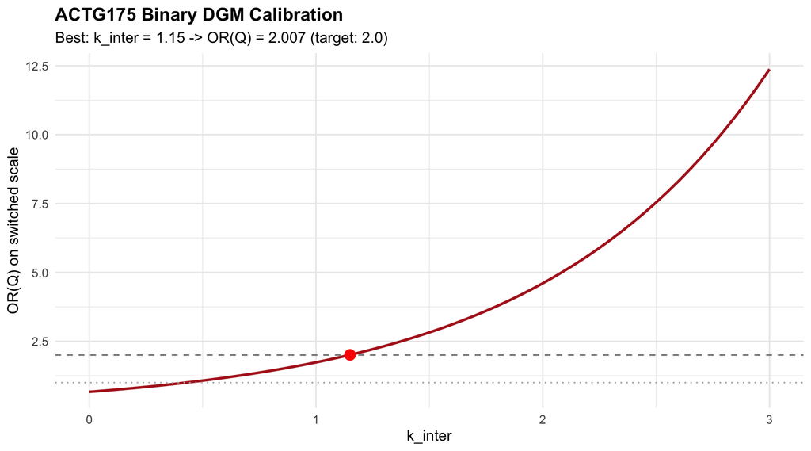

Calibration of k_inter: OR(Q) as a function of the interaction parameter.

```r
cal_grid <- seq(cal_k_grid_range[1], cal_k_grid_range[2], by = cal_grid_step)
cal_or_Q <- vapply(cal_grid, function(k) {
  d <- generate_glm_dgm(
    data = actg_df, factor_vars = dgm_factor_vars,
    outcome_var = "y_binary", treatment_var = "treat",
    outcome_type = "binary", subgroup_vars = dgm_subgroup_vars,
    subgroup_cuts = dgm_subgroup_cuts, model = "alt",
    k_inter = k, n_super = dgm_n_super, seed = sim_seed
  )
  d$hazard_ratios$harm_subgroup
}, numeric(1))

cal_df <- data.frame(k_inter = cal_grid, or_Q = cal_or_Q)
best_k <- dgm_calibrated$model_params$k_inter

ggplot(cal_df, aes(x = k_inter, y = or_Q)) +
  geom_line(linewidth = 1, colour = "firebrick") +
  geom_hline(yintercept = cal_target_or, linetype = "dashed",
             colour = "grey50") +
  geom_hline(yintercept = 1.0, linetype = "dotted",
             colour = "grey70") +
  geom_point(
    data = data.frame(k_inter = best_k,
                      or_Q = dgm_calibrated$hazard_ratios$harm_subgroup),
    colour = "red", size = 4, shape = 16
  ) +
  labs(
    x = "k_inter",
    y = "OR(Q) on switched scale",
    title = "ACTG175 Binary DGM Calibration",
    subtitle = sprintf(
      "Best: k_inter = %.2f -> OR(Q) = %.3f (target: %.1f)",
      best_k, dgm_calibrated$hazard_ratios$harm_subgroup, cal_target_or
    )
  ) +
  theme_minimal(base_size = 12) +
  theme(plot.title = element_text(face = "bold"))
```

## 4.3 Step 3: Create Null DGM

Under `model = "null"`, the treatment effect is **homogeneous** across all patients (no treatment effect heterogeneity). Per León et al. (2024, Section 3), $Q = \emptyset$ and $Q^c$ is the ITT population. The `flag_harm` column is retained as a structural label in the simulated data (marking $z_1 = 1 \cap z_2 = 1$) but has **no treatment-effect meaning**: there is no true benefit subgroup under this hypothesis.

```r
t0 <- proc.time()[3]

dgm_null <- generate_glm_dgm(
  data          = actg_df,
  factor_vars   = dgm_factor_vars,
  outcome_var   = "y_binary",
  treatment_var = "treat",
  outcome_type  = "binary",
  subgroup_vars = dgm_subgroup_vars,
  subgroup_cuts = dgm_subgroup_cuts,
  model         = "null",
  n_super       = dgm_n_super,
  seed          = sim_seed,
  verbose       = TRUE
)
```

```
#> === generate_glm_dgm() ===
#>   outcome_type:   binary
#>   effect_measure: OR
#>   model:          null
#>   k_inter:        0.000
#>   k_treat:        1.000
#>   n_super:        5000
#>   n observations: 1083
#>   Dropped single-level factors: z4
#>
#> === Subgroup Definitions ===
#>    z1 == 1
#>     Proportion in subgroup: 0.488
#>    z2 == 1
#>     Proportion in subgroup: 0.75
#>
#> Overall subgroup (all conditions met):
#>   Size: 382 out of 1083
#>   Proportion: 0.353
#>
#> Baseline GLM fit (no interaction):
#>   AIC: 1411.2
#>   Treatment coefficient: -0.4269 (OR = 0.653)
#>   Interaction shift (k_inter): 0.0000 (null model: forced to 0)
#>
#> === DGM Summary ===
#>   Effect(Q):   NA  (OR)
#>   Effect(Qc):  0.6678  (OR)
#>   Effect(ITT): 0.6678  (OR)
#>   Subgroup prevalence: 0.0%
```

```r
cat("\n=== ACTG175 Null DGM ===\n")
```

```
#>
#> === ACTG175 Null DGM ===
```

```r
cat("  OR(ITT):", round(dgm_null$hazard_ratios$overall, 3), "\n")
```

```
#>   OR(ITT): 0.668
```

```r
cat("  OR(Q):  ", round(dgm_null$hazard_ratios$harm_subgroup, 3), "\n")
```

```
#>   OR(Q):   NA
```

```r
cat("  OR(Qc): ", round(dgm_null$hazard_ratios$no_harm_subgroup, 3), "\n")
```

```
#>   OR(Qc):  0.668
```

```r
timings$dgm_null <- proc.time()[3] - t0
```

# 5 Single-Data Analysis

**ImportantReal-data setting: the ‘true’ subgroup is hypothetical**

This section analyses the **actual ACTG175 data** – not a simulated trial. The true benefit subgroup in a real trial is **unknown**; it is the object the analysis is trying to estimate.

For the package’s classification machinery to report values, however, some reference subgroup must be supplied as `flag_harm_ref`. Here we use the anchor $Q_{\text{ref}} = \{\text{age} > 34\} \cap \{\text{preanti} \le 744.5\}$ because this is the subgroup around which the **simulation DGM is calibrated** (see Section 4). It is the natural reference for judging whether the method recovers the DGM-embedded signal in the observed data, **but it is not an oracle claim about clinical truth**.

As a consequence, the TP / FP / FN / TN / sensitivity / specificity / PPV values reported below for the single-data FS run are best read as **“agreement with the DGM-anchoring subgroup”**, not as classification-against-truth. On genuinely unseen real data with no simulation DGM attached, these metrics are not defined and should not be reported.

Before any simulation, run ForestSearch on the **actual ACTG175 data** with `details = TRUE` to examine every step of the procedure: LASSO screening, GRF variable importance, candidate enumeration, and bootstrap consistency.

The analysis uses the **realistic candidate set**:

**Echo candidate covariate set (click to expand)**

```r
cat("Analysis candidate covariates (no oracle cuts):\n")
cat("  Continuous:", paste(analysis_continuous_vars, collapse = ", "), "\n")
cat("  Binary:    ", paste(analysis_binary_vars, collapse = ", "), "\n")
cat("\nForestsearch / GRF will discover cuts on the continuous\n")
cat("covariates themselves; the TRUE cuts (age > 34, preanti <= 745)\n")
cat("are NOT provided.\n")
```

**NoteWhat the analysis methods see**

The analysis candidate set (passed to `forestsearch()` / `grf.subg.harm.glm()` as `confounders.name`) is:

- **Continuous** (6): age, preanti, wtkg, karnof, cd40, cd80
- **Binary** (6): hemo, homo, drugs, race, gender, symptom

The methods discover cuts on the continuous covariates themselves; the TRUE cuts (age $>$ 34, preanti $\le$ 744.5) are **not** provided.

**fs_run() on real data (click to expand)**

```r
t0 <- proc.time()[3]

# ForestSearch on ACTG175 observed data
#   outcome_type = 'binary', effect_measure = 'OR'
#   Treatment: switched (ddI = 1, ZDV+ddI = 0)
#   Y = I(cd420 > cd40) = improvement
#   Covariates: RAW continuous + binary indicators
#   Thresholds: c1 = fs_or_threshold, c2 = fs_or_consistency

fs_actg <- fs_run(
  data        = actg_df,
  outcome_col = "y_binary",
  event_col   = "y_binary",
  treat_col   = "treat",
  id_col      = "id"
)
```

```
#>
#> [forestsearch] Subgroup Identification Configuration
#>   Outcome type:   binary
#>   Effect measure: OR (Odds Ratio)
#>   Scale:          log (ratio)
#>
#>   Screening:      OR >= 1.67 (log: 0.5110)
#>   Consistency:    OR >= 1.33 (log: 0.2874)
#>   Consistency rate threshold: 80%
#>
#>   Interpretation:
#>     Candidates: subgroup OR >= 1.67
#>     Splits:     each split OR >= 1.33
```

```
#>   Search Alignment Diagnostic
```

```
#>
#>   Outcome:    y_binary (binary)
```

```
#>   Treatment:  treat
```

```
#>   Measure:    Odds Ratio (OR) -- estimator sees Y as-is (no flip)
```

```
#>
#>   ForestSearch searches for:
#>     Subgroups where treat increases P(y_binary=1)
#>     (OR >= threshold on the ORIGINAL outcome scale)
```

```
#>
#>   Thresholds:
#>     Screening: OR >= 1.667 in the candidate subgroup
#>     Consistency: OR >= 1.333 in each bootstrap split
```

```
#>
#>   Variable screening:
```

```
#>     LASSO: LASSO screening: DISABLED
```

```
#>     GRF:   GRF sees 1-y_binary (flipped for causal_forest).
#>     Positive CATE = treatment REDUCES y_binary = treatment HELPS.
```

```
#>
#>   No alignment concerns detected.
```

```
#> GRF subgroup: wtkg <= 83.46 & preanti <= 1292 & cd40 <= 390
#> GRF cuts identified: 3
#>   Cuts: wtkg <= 83.4624, preanti <= 1292, cd40 <= 390
#> Candidate factors: 31
#>  [1] "wtkg <= 83.4624"  "preanti <= 1292"  "cd40 <= 390"      "age <= 35.2"
#>  [5] "age <= 34"        "age <= 29"        "age <= 40"        "preanti <= 381.6"
#>  [9] "preanti <= 136"   "preanti <= 0"     "preanti <= 744.5" "wtkg <= 74.9"
#> [13] "wtkg <= 74.4"     "wtkg <= 66.5"     "wtkg <= 82.2"     "karnof <= 95.3"
#> [17] "karnof <= 90"     "cd40 <= 348.1"    "cd40 <= 338"      "cd40 <= 259.5"
#> [21] "cd40 <= 421"      "cd80 <= 987.5"    "cd80 <= 895"      "cd80 <= 648.5"
#> [25] "cd80 <= 1208"     "hemo"             "homo"             "drugs"
#> [29] "race"             "gender"           "symptom"
#> Number of possible configurations (<= maxk): maxk = 2 , # combinations = 1953
#> Per-arm events criteria: control >= 10, treatment >= 10
#> Sample size criteria: n >= 60
#> Subgroup search completed in 0.03 minutes
#>
#> --- Filtering Summary ---
#>   Combinations evaluated: 1953
#>   Passed variance check: 1878
#>   Passed prevalence (>= 0.025 ): 1878
#>   Passed redundancy check: 1827
#>   Passed events counts (d0>= 10, d1>= 10): 1717
#>   Passed sample size (n>= 60 ): 1669
#>   GLM model fit successfully: 1669
#>   Passed effect threshold (OR >= 1.667): 6
#> -------------------------
#>
#> Found 6 subgroup candidate(s)
#> # of candidate subgroups (meeting all criteria) = 6
#> # of unique initial candidates: 6
#> # Restricting to top stop_Kgroups = 10
#> # of candidates to evaluate: 6
#> # Early stop threshold: 0.95
#> Parallel config: workers = 1 , batch_size = 1
#> Batch 1 / 6 : candidates 1 - 1
#> Batch 2 / 6 : candidates 2 - 2
#> Batch 3 / 6 : candidates 3 - 3
#> Batch 4 / 6 : candidates 4 - 4
#>
#> ==================================================
#> EARLY STOP TRIGGERED (batch 4 )
#>   Candidate: 4 of 6
#>   Pcons: 1 >= 0.95
#> ==================================================
#>
#> Evaluated 4 of 6 candidates (early stop)
#> 2 subgroups passed consistency threshold
#> SG focus = maxSG
#> Seconds and minutes forestsearch overall = 2.563 0.0427
#> Consistency algorithm used: twostage
#> Subgroup identified: !{cd40 <= 390} & !{wtkg <= 82.2}
```

**fs_run() on real data (click to expand)**

```r
timings$single_data <- proc.time()[3] - t0
```

## 5.1 Examine Result

**Examine FS result + subgroup OR fits (click to expand)**

```r
cat("\n=== ForestSearch Result ===\n")
```

```
#>
#> === ForestSearch Result ===
```

**Examine FS result + subgroup OR fits (click to expand)**

```r
if (!is.null(fs_actg$grp.consistency)) {
  # NOTE: for a forestsearch object, the cut expressions defining the
  # identified subgroup live in `grp.consistency$sg.harm` (character
  # vector of factor-level cut names).  `grp.consistency$sg.harm.id`
  # is a different object: a per-subject 0/1 indicator of subgroup
  # membership with length nrow(df).  (For GRF objects, `sg.harm.id`
  # does carry the cut expressions — same name, different semantics.)
  sg <- fs_actg$grp.consistency$sg.harm
  if (!is.null(sg) && length(sg) > 0 && !all(is.na(sg))) {
    cat("Subgroup identified:", paste(sg, collapse = " & "), "\n")

    df_est <- fs_actg$df.est
    in_H  <- df_est$treat.recommend == 0
    in_Hc <- df_est$treat.recommend == 1

    cat(sprintf("  Size(H): %d,  Size(Hc): %d\n",
        sum(in_H), sum(in_Hc)))

    if (sum(in_H) >= 10) {
      fit_H <- glm(y_binary ~ treat, data = df_est[in_H, ],
                    family = binomial)
      or_H <- exp(coef(fit_H)["treat"])
      cat(sprintf("  OR(H, switched):  %.3f  (inverted: %.3f)\n",
          or_H, 1/or_H))
    }
    if (sum(in_Hc) >= 10) {
      fit_Hc <- glm(y_binary ~ treat, data = df_est[in_Hc, ],
                     family = binomial)
      or_Hc <- exp(coef(fit_Hc)["treat"])
      cat(sprintf("  OR(Hc, switched): %.3f  (inverted: %.3f)\n",
          or_Hc, 1/or_Hc))
    }

    fit_itt <- glm(y_binary ~ treat, data = df_est, family = binomial)
    cat(sprintf("  OR(ITT, switched): %.3f\n",
        exp(coef(fit_itt)["treat"])))

    # --------------------------------------------------------------------
    # CLASSIFICATION AGAINST THE DGM-ANCHORING SUBGROUP (HYPOTHETICAL)
    # --------------------------------------------------------------------
    # On real data the clinical truth is unknown.  We report these
    # quantities only as a hypothetical benchmark: if the true benefit
    # subgroup were the DGM anchor Q_ref (below), what would the
    # FS-identified subgroup's agreement with it look like?
    # See the callout at the top of this section.
    #
    # The arithmetic is factored out into classification_metrics()
    # (defined in the prepare-datasets chunk) which mirrors the
    # simulation-loop computation in run_simulation_analysis().  Tables
    # are printed in the chunk that follows.
    cls_fs_actg <- classification_metrics(
      hat_H       = (df_est$treat.recommend == 0),
      true_H      = (df_est$flag_harm_ref == 1),
      title       = "ForestSearch on observed ACTG175: classification metrics",
      show_npv    = FALSE,
      truth_label = sprintf(
        "DGM-anchoring subgroup Q_ref = {age > %d AND preanti \u2264 %.1f} (NOT clinical truth)",
        actg_age_cut, actg_preanti_cut))
  } else {
    cat("No subgroup identified by ForestSearch.\n")
    cls_fs_actg <- NULL
  }
} else {
  cat("ForestSearch did not return grp.consistency.\n")
  cls_fs_actg <- NULL
}
```

```
#> Subgroup identified: !{cd40 <= 390} & !{wtkg <= 82.2}
#>   Size(H): 93,  Size(Hc): 990
#>   OR(H, switched):  3.690  (inverted: 0.271)
#>   OR(Hc, switched): 0.562  (inverted: 1.780)
#>   OR(ITT, switched): 0.665
```

**Examine FS result + subgroup OR fits (click to expand)**

```r
cat(sprintf("\nSingle-data analysis: %.1f sec\n", timings$single_data))
```

```
#>
#> Single-data analysis: 2.6 sec
```

```r
# gt tables render reliably when they're the last expression of a chunk.
# Inside a conditional (or when piped through print()), knitr does not
# always dispatch the gt print method — it falls back to printing the
# raw HTML source as text.  Emitting gt::as_raw_html() via cat() under
# `results: asis` is the canonical workaround and works in every knitr
# context.
if (!is.null(cls_fs_actg)) {
  cat(gt::as_raw_html(cls_fs_actg$table_counts),  "\n\n")
  cat(gt::as_raw_html(cls_fs_actg$table_metrics), "\n\n")
}
```

ForestSearch on observed ACTG175: classification metrics

Truth reference: DGM-anchoring subgroup Q_ref = {age > 34 AND preanti ≤ 744.5} (NOT clinical truth)

| Metric | n(H-hat) | n(true H) | TP | FP | FN | TN |
| --- | --- | --- | --- | --- | --- | --- |
| Counts | 93 | 382 | 40 | 53 | 342 | 648 |

| Metric | Sens | Spec | PPV |
| --- | --- | --- | --- |
| Rates | 0.105 | 0.924 | 0.430 |

## 5.2 GRF Standalone on Observed Data

**GRF standalone call + output (click to expand)**

```r
grf_actg <- grf.subg.harm.glm(
  data             = actg_df,
  confounders.name = confounders_analysis,
  outcome.name     = "y_binary",
  treat.name       = "treat",
  id.name          = "id",
  outcome_type     = "binary",
  effect_measure   = "OR",
  dmin.grf         = grf_dmin,
  maxdepth         = grf_maxdepth,
  RCT              = TRUE,
  sg.criterion     = grf_sg_criterion,
  details          = TRUE
)

if (!is.null(grf_actg$sg.harm.id) && length(grf_actg$sg.harm.id) > 0) {
  cat("GRF subgroup:", paste(grf_actg$sg.harm.id, collapse = " & "), "\n")
  grf_H <- grf_actg$data$treat.recommend == 0
  cat(sprintf("  Size(H): %d,  Size(Hc): %d\n",
      sum(grf_H), sum(!grf_H)))
} else {
  cat("GRF: no subgroup identified.\n")
}
```

```
#> GRF subgroup: wtkg <= 83.46 & preanti <= 1292 & cd40 <= 390
#>   Size(H): 953,  Size(Hc): 130
```

## 5.3 FS vs GRF Concordance on Observed Data

When a method does not detect a subgroup, its classification is “all subjects to $Q^c$” (`treat.recommend = 1` for everyone). `compare_fs_subgroups()` handles this automatically — no manual fallback is needed.

```r
sg_compare <- compare_fs_subgroups(
  fs1                = fs_actg,
  fs2                = grf_actg,
  label1             = "ForestSearch",
  label2             = "GRF Standalone",
  id.name            = "id",
  subgroup_notation  = sg_notation,
  title              = "FS vs GRF: Subgroup Membership Concordance",
  subtitle           = "ACTG175 observed data (binary benefit search, raw continuous)",
  font_size          = 13
)

sg_compare$table
```

**FS vs GRF: Subgroup Membership Concordance**

ACTG175 observed data (binary benefit search, raw continuous)

| ForestSearch | GRF Standalone Q (Benefit) | GRF Standalone Qᶜ (No benefit) | Total |  |
| --- | --- | --- | --- | --- |
| Q (Benefit) | 10 | 83 |  | 93 |
| Qᶜ (No benefit) | 943 | 47 | 990 |  |
| Total | 953 | 130 | 1083 |  |

**Agreement:** 57 / 1083 (5.3%) **Cohen’s κ:** -0.163 **ForestSearch H:** !{cd40 <= 390} & !{wtkg <= 82.2} **GRF Standalone H:** wtkg <= 83.46 & preanti <= 1292 & cd40 <= 390

```r
cat("Concordance statistics:\n")
```

```
#> Concordance statistics:
```

```r
cat(sprintf("  Agreement: %.1f%%\n",
    100 * sg_compare$concordance$agreement))
```

```
#>   Agreement: 5.3%
```

```r
cat(sprintf("  Cohen's kappa: %.3f\n",
    sg_compare$concordance$kappa))
```

```
#>   Cohen's kappa: -0.163
```

```r
cat(sprintf("  Concordant: %d / Discordant: %d / Total: %d\n",
    sg_compare$concordance$n_agree,
    sg_compare$concordance$n_disagree,
    sg_compare$concordance$n_total))
```

```
#>   Concordant: 57 / Discordant: 1026 / Total: 1083
```

# 6 Single Trial Simulation

Unlike Section 5, the **true subgroup here is known by construction** (it is the DGM-embedded Q), so the classification metrics reported below are valid TP / FP / FN / TN values against an actual ground truth.

**Simulate one trial from the calibrated DGM (click to expand)**

```r
t0 <- proc.time()[3]

# ── Simulate one trial from the calibrated DGM ─────────────────────────
df_single <- simulate_from_glm_dgm(
  dgm  = dgm_calibrated,
  n    = sim_n_sample,
  seed = sim_seed + 1L
)

cat(sprintf("Single trial: N = %d, response rate = %.1f%%\n",
    nrow(df_single), 100 * mean(df_single$y_sim)))
```

```
#> Single trial: N = 1000, response rate = 65.9%
```

**Simulate one trial from the calibrated DGM (click to expand)**

```r
cat(sprintf("  treat allocation: %.1f%%\n",
    100 * mean(df_single$treat_sim)))
```

```
#>   treat allocation: 49.1%
```

**Simulate one trial from the calibrated DGM (click to expand)**

```r
cat(sprintf("  True Q prevalence: %.1f%%\n",
    100 * mean(df_single$flag_harm)))
```

```
#>   True Q prevalence: 35.5%
```

**Simulate one trial from the calibrated DGM (click to expand)**

```r
# ── Verify OR in the simulated data ───────────────────────────────────
fit_single <- glm(y_sim ~ treat_sim, data = df_single, family = binomial)
cat(sprintf("  Simulated ITT OR: %.3f (DGM target: %.3f)\n",
    exp(coef(fit_single)["treat_sim"]),
    dgm_calibrated$hazard_ratios$overall))
```

```
#>   Simulated ITT OR: 0.858 (DGM target: 0.919)
```

**Simulate one trial from the calibrated DGM (click to expand)**

```r
# ── Confirm raw continuous columns are present in simulated data ──────
missing_in_sim <- setdiff(confounders_analysis, names(df_single))
if (length(missing_in_sim) > 0) {
  stop("Simulated data is missing analysis columns: ",
       paste(missing_in_sim, collapse = ", "))
}
```

## 6.1 ForestSearch on the Simulated Trial

**fs_run() on the simulated trial (click to expand)**

```r
# Ensure a stable id column for compare_fs_subgroups() alignment
df_single$id <- seq_len(nrow(df_single))

fs_single <- fs_run(
  data        = df_single,
  outcome_col = "y_sim",
  event_col   = "y_sim",
  treat_col   = "treat_sim",
  id_col      = "id"
)
```

```
#>
#> [forestsearch] Subgroup Identification Configuration
#>   Outcome type:   binary
#>   Effect measure: OR (Odds Ratio)
#>   Scale:          log (ratio)
#>
#>   Screening:      OR >= 1.67 (log: 0.5110)
#>   Consistency:    OR >= 1.33 (log: 0.2874)
#>   Consistency rate threshold: 80%
#>
#>   Interpretation:
#>     Candidates: subgroup OR >= 1.67
#>     Splits:     each split OR >= 1.33
```

```
#>   Search Alignment Diagnostic
```

```
#>
#>   Outcome:    y_sim (binary)
```

```
#>   Treatment:  treat_sim
```

```
#>   Measure:    Odds Ratio (OR) -- estimator sees Y as-is (no flip)
```

```
#>
#>   ForestSearch searches for:
#>     Subgroups where treat_sim increases P(y_sim=1)
#>     (OR >= threshold on the ORIGINAL outcome scale)
```

```
#>
#>   Thresholds:
#>     Screening: OR >= 1.667 in the candidate subgroup
#>     Consistency: OR >= 1.333 in each bootstrap split
```

```
#>
#>   Variable screening:
```

```
#>     LASSO: LASSO screening: DISABLED
```

```
#>     GRF:   GRF sees 1-y_sim (flipped for causal_forest).
#>     Positive CATE = treatment REDUCES y_sim = treatment HELPS.
```

```
#>
#>   No alignment concerns detected.
```

```
#> GRF subgroup: cd40 <= 304 & preanti <= 206 & wtkg <= 78.02
#> GRF cuts identified: 3
#>   Cuts: cd40 <= 304, preanti <= 206, wtkg <= 78.0192
#> Candidate factors: 31
#>  [1] "cd40 <= 304"      "preanti <= 206"   "wtkg <= 78.0192"  "age <= 35.2"
#>  [5] "age <= 34"        "age <= 29"        "age <= 40"        "preanti <= 363.5"
#>  [9] "preanti <= 122"   "preanti <= 0"     "preanti <= 741"   "wtkg <= 76"
#> [13] "wtkg <= 75.3"     "wtkg <= 67.1"     "wtkg <= 83.5"     "karnof <= 95.3"
#> [17] "karnof <= 90"     "cd40 <= 343.6"    "cd40 <= 327"      "cd40 <= 257"
#> [21] "cd40 <= 412"      "cd80 <= 983.6"    "cd80 <= 873"      "cd80 <= 640"
#> [25] "cd80 <= 1192.5"   "hemo"             "homo"             "drugs"
#> [29] "race"             "gender"           "symptom"
#> Number of possible configurations (<= maxk): maxk = 2 , # combinations = 1953
#> Per-arm events criteria: control >= 10, treatment >= 10
#> Sample size criteria: n >= 60
#> Subgroup search completed in 0.03 minutes
#>
#> --- Filtering Summary ---
#>   Combinations evaluated: 1953
#>   Passed variance check: 1878
#>   Passed prevalence (>= 0.025 ): 1878
#>   Passed redundancy check: 1830
#>   Passed events counts (d0>= 10, d1>= 10): 1772
#>   Passed sample size (n>= 60 ): 1722
#>   GLM model fit successfully: 1722
#>   Passed effect threshold (OR >= 1.667): 77
#> -------------------------
#>
#> Found 77 subgroup candidate(s)
#> # of candidate subgroups (meeting all criteria) = 77
#> Removed 5 near-duplicate subgroups
#> # of unique initial candidates: 72
#> # Restricting to top stop_Kgroups = 10
#> # of candidates to evaluate: 10
#> # Early stop threshold: 0.95
#> Parallel config: workers = 1 , batch_size = 1
#> Batch 1 / 10 : candidates 1 - 1
#> Batch 2 / 10 : candidates 2 - 2
#> Batch 3 / 10 : candidates 3 - 3
#> Batch 4 / 10 : candidates 4 - 4
#> Batch 5 / 10 : candidates 5 - 5
#> Batch 6 / 10 : candidates 6 - 6
#> Batch 7 / 10 : candidates 7 - 7
#> Batch 8 / 10 : candidates 8 - 8
#> Batch 9 / 10 : candidates 9 - 9
#> Batch 10 / 10 : candidates 10 - 10
#> Evaluated 10 of 10 candidates (complete)
#> 2 subgroups passed consistency threshold
#> SG focus = maxSG
#> Seconds and minutes forestsearch overall = 4.053 0.0676
#> Consistency algorithm used: twostage
#> Subgroup identified: !{wtkg <= 75.3} & !{karnof <= 90}
```

**Examine FS result on simulated trial (click to expand)**

```r
cat("\n=== ForestSearch on simulated trial ===\n")
```

```
#>
#> === ForestSearch on simulated trial ===
```

**Examine FS result on simulated trial (click to expand)**

```r
if (!is.null(fs_single$sg.harm) && length(fs_single$sg.harm) > 0L &&
    !all(is.na(fs_single$sg.harm))) {

  cat("Subgroup identified (cut expressions):\n")
  for (s in fs_single$sg.harm) cat("  ", s, "\n")

  df_est <- fs_single$df.est
  in_H   <- df_est$treat.recommend == 0

  # Classification against the KNOWN true subgroup in simulated data.
  # Factored helper in the prepare-datasets chunk; tables are printed
  # in the chunk that follows.
  cls_fs_single <- classification_metrics(
    hat_H       = in_H,
    true_H      = (df_est$flag_harm == 1),
    title       = "ForestSearch on simulated trial: classification metrics",
    show_npv    = TRUE,
    truth_label = "Known true subgroup Q in the simulated data")

  # Subgroup effect on switched and original scales
  if (sum(in_H) >= 10L) {
    fit_H <- glm(y_sim ~ treat_sim,
                 data = df_est[in_H, ], family = binomial)
    or_H  <- exp(coef(fit_H)["treat_sim"])
    cat(sprintf("\n  OR(H_hat, switched) = %.3f  (inverted: %.3f)\n",
        or_H, 1/or_H))
  }
  if (sum(!in_H) >= 10L) {
    fit_Hc <- glm(y_sim ~ treat_sim,
                  data = df_est[!in_H, ], family = binomial)
    cat(sprintf("  OR(Hc_hat, switched) = %.3f  (inverted: %.3f)\n",
        exp(coef(fit_Hc)["treat_sim"]),
        1/exp(coef(fit_Hc)["treat_sim"])))
  }

} else {
  cat("No subgroup identified by ForestSearch on this replicate.\n")
  cls_fs_single <- NULL
}
```

```
#> Subgroup identified (cut expressions):
#>    !{wtkg <= 75.3}
#>    !{karnof <= 90}
#>
#>   OR(H_hat, switched) = 1.868  (inverted: 0.535)
#>   OR(Hc_hat, switched) = 0.656  (inverted: 1.523)
```

```r
if (!is.null(cls_fs_single)) {
  cat(gt::as_raw_html(cls_fs_single$table_counts),  "\n\n")
  cat(gt::as_raw_html(cls_fs_single$table_metrics), "\n\n")
}
```

ForestSearch on simulated trial: classification metrics

Truth reference: Known true subgroup Q in the simulated data

| Metric | n(H-hat) | n(true H) | TP | FP | FN | TN |
| --- | --- | --- | --- | --- | --- | --- |
| Counts | 271 | 355 | 129 | 142 | 226 | 503 |

| Metric | Sens | Spec | PPV | NPV |
| --- | --- | --- | --- | --- |
| Rates | 0.363 | 0.780 | 0.476 | 0.690 |

## 6.2 GRF Standalone on the Simulated Trial

**GRF call + output on simulated trial (click to expand)**

```r
grf_single <- grf.subg.harm.glm(
  data             = df_single,
  confounders.name = confounders_analysis,
  outcome.name     = "y_sim",
  treat.name       = "treat_sim",
  id.name          = "id",
  outcome_type     = "binary",
  effect_measure   = "OR",
  dmin.grf         = grf_dmin,
  maxdepth         = grf_maxdepth,
  RCT              = TRUE,
  sg.criterion     = grf_sg_criterion,
  details          = TRUE
)

cat("\n=== GRF standalone on simulated trial ===\n")
```

```
#>
#> === GRF standalone on simulated trial ===
```

**GRF call + output on simulated trial (click to expand)**

```r
if (!is.null(grf_single$sg.harm.id) &&
    length(grf_single$sg.harm.id) > 0L &&
    !all(is.na(grf_single$sg.harm.id))) {
  cat("GRF subgroup (cut expressions):\n")
  for (s in grf_single$sg.harm.id) cat("  ", s, "\n")

  grf_H  <- grf_single$data$treat.recommend == 0
  true_H <- grf_single$data$flag_harm == 1

  # Classification metrics via the same helper used for FS.  Tables
  # printed in the chunk that follows.
  cls_grf_single <- classification_metrics(
    hat_H       = grf_H,
    true_H      = true_H,
    title       = "GRF on simulated trial: classification metrics",
    show_npv    = TRUE,
    truth_label = "Known true subgroup Q in the simulated data")
} else {
  cat("GRF: no subgroup identified on this replicate.\n")
  cls_grf_single <- NULL
}
```

```
#> GRF subgroup (cut expressions):
#>    cd40 <= 303
#>    preanti <= 206
#>    wtkg <= 78.02
```

**GRF call + output on simulated trial (click to expand)**

```r
timings$single_trial <- proc.time()[3] - t0
cat(sprintf("\nSingle trial analysis: %.1f sec\n", timings$single_trial))
```

```
#>
#> Single trial analysis: 4.4 sec
```

```r
if (!is.null(cls_grf_single)) {
  cat(gt::as_raw_html(cls_grf_single$table_counts),  "\n\n")
  cat(gt::as_raw_html(cls_grf_single$table_metrics), "\n\n")
}
```

GRF on simulated trial: classification metrics

Truth reference: Known true subgroup Q in the simulated data

| Metric | n(H-hat) | n(true H) | TP | FP | FN | TN |
| --- | --- | --- | --- | --- | --- | --- |
| Counts | 547 | 355 | 149 | 398 | 206 | 247 |

| Metric | Sens | Spec | PPV | NPV |
| --- | --- | --- | --- | --- |
| Rates | 0.420 | 0.383 | 0.272 | 0.545 |

## 6.3 FS vs GRF Concordance on the Simulated Trial

**FS vs GRF agreement on simulated trial (click to expand)**

```r
sg_compare_sim <- compare_fs_subgroups(
  fs1                = fs_single,
  fs2                = grf_single,
  label1             = "ForestSearch",
  label2             = "GRF Standalone",
  id.name            = "id",
  subgroup_notation  = sg_notation,
  title              = "FS vs GRF on simulated trial",
  subtitle           = sprintf("N = %d, simulated from calibrated DGM",
                               nrow(df_single)),
  font_size          = 13
)
sg_compare_sim$table
```

**FS vs GRF on simulated trial**

N = 1000, simulated from calibrated DGM

| ForestSearch | GRF Standalone Q (Benefit) | GRF Standalone Qᶜ (No benefit) | Total |  |
| --- | --- | --- | --- | --- |
| Q (Benefit) | 68 | 203 |  | 271 |
| Qᶜ (No benefit) | 479 | 250 | 729 |  |
| Total | 547 | 453 | 1000 |  |

**Agreement:** 318 / 1000 (31.8%) **Cohen’s κ:** -0.308 **ForestSearch H:** !{wtkg <= 75.3} & !{karnof <= 90} **GRF Standalone H:** cd40 <= 303 & preanti <= 206 & wtkg <= 78.02

# 7 Running Simulation Studies

## 7.1 Setup

**FS / GRF parameter lists for run_simulation_analysis() (click to expand)**

```r
plan(multisession, workers = n_workers)
cat("Using", n_workers, "parallel workers\n")
```

```
#> Using 13 parallel workers
```

**FS / GRF parameter lists for run_simulation_analysis() (click to expand)**

```r
# -- Candidate variable set (RAW continuous + binary) --------------------------
# This is the key behavioural change vs the prior discretised setup:
# forestsearch() and grf.subg.harm.glm() receive raw continuous inputs
# and must discover cuts.
cat("Analysis confounders passed to FS/GRF:\n")
```

```
#> Analysis confounders passed to FS/GRF:
```

**FS / GRF parameter lists for run_simulation_analysis() (click to expand)**

```r
cat("  ", paste(confounders_analysis, collapse = ", "), "\n")
```

```
#>    age, preanti, wtkg, karnof, cd40, cd80, hemo, homo, drugs, race, gender, symptom
```

**FS / GRF parameter lists for run_simulation_analysis() (click to expand)**

```r
# -- ForestSearch parameters ---------------------------------------------------
fs_params <- list(
  # Column name mappings
  outcome.name           = "y_sim",
  event.name             = "y_sim",
  treat.name             = "treat_sim",
  id.name                = "id",

  # GLM pipeline
  outcome_type           = "binary",
  effect_measure         = "OR",

  # Variable screening
  use_lasso              = fs_use_lasso,
  use_grf                = fs_use_grf,

  # Consistency algorithm (v0.2.0 default: 3-10x speedup)
  use_twostage           = TRUE,

  # Continuous-variable detection threshold
  cont.cutoff            = fs_cont_cutoff,

  # Candidate cut strategy for continuous covariates
  # ("default" = mean + median + Q1 + Q3 per continuous variable;
  #  "median"  = median only). See setup chunk for full explanation.
  cut_type               = fs_cut_type,

  # Subgroup detection thresholds
  # Note: hr.threshold/hr.consistency are the generic ForestSearch
  # parameter names regardless of endpoint type. For binary outcomes,
  # these represent OR thresholds on the switched scale.
  hr.threshold           = fs_or_threshold,
  hr.consistency         = fs_or_consistency,
  pconsistency.threshold = fs_pconsistency,

  # Candidate-selection criterion: "maxSG" prefers the LARGEST
  # candidate subgroup meeting the consistency threshold (see setup
  # chunk for full description of sg_focus options).
  sg_focus               = fs_sg_focus,

  # Computational constraints
  fs.splits              = fs_splits,
  n.min                  = fs_n_min,
  d0.min                 = fs_d0_min,
  d1.min                 = fs_d1_min,
  maxk                   = fs_maxk,
  vi.grf.min             = fs_vi_grf_min,
  seedit                 = fs_seedit,

  # GRF tuning (applies to ForestSearch's internal GRF pre-screening)
  tune_grf               = grf_tune,

  # Inner parallelism: sequential within each worker
  parallel_args          = list(
    plan = "sequential", workers = 1, show_message = FALSE
  )
)

# -- GRF standalone parameter overrides ----------------------------------------
grf_params <- list(
  dmin.grf     = grf_dmin,
  maxdepth     = grf_maxdepth,
  sg.criterion = grf_sg_criterion,
  tune_grf     = grf_tune
)
```

## 7.2 Alternative Hypothesis Simulations

**H1 simulation loop — foreach wiring + run_simulation_analysis() (click to expand)**

```r
cat("Running", nsims_alt, "simulations under H1...\n")
if (diag_keep_first_n > 0L) {
  cat(sprintf("  Diagnostic capture: keep = {%s}, first %d sim(s)\n",
      paste(diag_keep, collapse = ", "), diag_keep_first_n))
}
t0 <- proc.time()[3]

results_alt_raw <- foreach(
  sim = seq_len(nsims_alt),
  .errorhandling = "pass",
  .options.future = list(
    packages = c("forestsearch", "survival", "data.table", "future"),
    seed = TRUE
  )
) %dofuture% {
  future::plan("sequential")
  run_simulation_analysis(
    sim_id           = sim,
    dgm              = dgm_calibrated,
    n_sample         = sim_n_sample,
    confounders_base = confounders_analysis,
    n_add_noise      = sim_n_noise,
    run_fs           = run_fs,
    run_fs_grf       = run_fs_grf,
    run_grf          = run_grf,
    fs_params        = fs_params,
    grf_params       = grf_params,
    keep             = diag_keep,
    keep_first_n     = diag_keep_first_n,
    verbose          = FALSE
  )
}

timings$sims_alt <- proc.time()[3] - t0

# Post-hoc failure accounting + diagnostic harvest
# keep_diagnostics = TRUE preserves per-replicate fs_full / candidate_table
# attached by run_simulation_analysis() (stripped by rbindlist otherwise).
results_alt <- collect_results(results_alt_raw, "H1 alt",
                               keep_diagnostics = diag_keep_first_n > 0L)
n_failed_alt <- attr(results_alt, "n_failed")
diagnostics_alt <- attr(results_alt, "diagnostics")

cat("Completed in", round(timings$sims_alt / 60, 1), "minutes\n")
cat("Results:", nrow(results_alt), "rows\n")
if (n_failed_alt > 0) cat(sprintf("  *** %d FAILED ***\n", n_failed_alt))
if (!is.null(diagnostics_alt))
  cat(sprintf("  Diagnostic objects captured: %d replicate(s)\n",
      length(diagnostics_alt)))
if (nrow(results_alt) > 0) {
  cat(sprintf("Detection rate: %.1f%%\n",
      100 * mean(results_alt$any.H[results_alt$analysis == "FS"])))
} else {
  cat("All simulations failed — see error messages above.\n")
  cat("Common causes:\n")
  cat("  1. devtools::document() -> devtools::install() -> restart R needed\n")
  cat("  2. Package version mismatch between interactive and worker sessions\n")
}
```

[output not shown]

## 7.3 ForestSearch Sensitivity Diagnostic

**NoteWhy this section exists**

### 7.3.1 Per-replicate subgroup definitions (first 20)

The `sg.def` column on `results_alt` carries the cut-expression string of the FS-identified subgroup for **every** replicate (a v0.2.0 addition to `run_simulation_analysis()`). We print the first 20 alongside the corresponding sensitivity / PPV / size for context.

**First N FS subgroup definitions (click to expand)**

```r
fs_rows <- results_alt[results_alt$analysis == "FS", ]
show_n  <- min(20L, nrow(fs_rows))

diag_tbl <- data.frame(
  sim      = fs_rows$sim[seq_len(show_n)],
  any.H    = fs_rows$any.H[seq_len(show_n)],
  size.H   = fs_rows$size.H[seq_len(show_n)],
  sens     = round(fs_rows$sens[seq_len(show_n)], 3),
  ppv      = round(fs_rows$ppv[seq_len(show_n)],  3),
  sg.def   = fs_rows$sg.def[seq_len(show_n)],
  stringsAsFactors = FALSE
)

diag_tbl$sg.def[!nzchar(diag_tbl$sg.def)] <- "(none identified)"

knitr::kable(
  diag_tbl,
  col.names = c("Sim", "any.H", "|H_hat|", "Sens", "PPV",
                "Identified subgroup"),
  caption = sprintf(
    "First %d H1 replicates: FS-identified subgroup definitions.",
    show_n),
  align = c("r", "c", "r", "r", "r", "l")
)
```

First 20 H1 replicates: FS-identified subgroup definitions.

| Sim | any.H | \|H_hat\| | Sens | PPV | Identified subgroup |
| --- | --- | --- | --- | --- | --- |
| 1 | 1 | 343 | 0.977 | 1.000 | !{age <= 34} & {preanti <= 694.2} |
| 2 | 1 | 337 | 1.000 | 0.976 | {preanti <= 762} & !{age <= 34} |
| 3 | 1 | 272 | 0.599 | 0.746 | !{age <= 34.8} & {age <= 41} |
| 4 | 1 | 435 | 0.614 | 0.501 | !{wtkg <= 74.7} & !{age <= 28} |
| 5 | 1 | 346 | 0.737 | 0.705 | !{age <= 34} & {cd80 <= 1180} |
| 6 | 1 | 161 | 0.235 | 0.503 | {homo} & {cd40 <= 252} |
| 7 | 1 | 448 | 0.922 | 0.717 | !{wtkg <= 60} & !{age <= 34.9} |
| 8 | 1 | 386 | 0.831 | 0.741 | !{age <= 36} & !{hemo} |
| 9 | 1 | 281 | 0.605 | 0.737 | !{age <= 34.9} & {cd40 <= 352} |
| 10 | 0 | 0 | 0.000 | 0.000 | (none identified) |
| 11 | 1 | 541 | 0.935 | 0.638 | !{age <= 29} & {preanti <= 630} |
| 12 | 1 | 380 | 1.000 | 0.905 | !{age <= 34} & {preanti <= 866} |
| 13 | 1 | 504 | 0.958 | 0.720 | !{age <= 30} & {preanti <= 678} |
| 14 | 1 | 365 | 0.997 | 0.836 | {preanti <= 739} & !{age <= 32} |
| 15 | 1 | 413 | 0.850 | 0.712 | !{age <= 34} & !{cd40 <= 231} |
| 16 | 1 | 229 | 0.622 | 1.000 | !{age <= 38} & {preanti <= 715.8} |
| 17 | 1 | 330 | 0.882 | 1.000 | !{age <= 34} & {preanti <= 551} |
| 18 | 1 | 431 | 0.778 | 0.636 | !{age <= 33} & !{symptom} |
| 19 | 1 | 321 | 0.985 | 1.000 | !{age <= 34} & {preanti <= 715.5} |
| 20 | 1 | 200 | 0.275 | 0.475 | !{age <= 29} & {race} |

### 7.3.2 Cross-replicate subgroup-definition frequency (all sims)

**Cross-replicate subgroup-definition frequency (click to expand)**

```r
all_defs <- fs_rows$sg.def
all_defs[!nzchar(all_defs)] <- "(none identified)"

def_freq <- sort(table(all_defs), decreasing = TRUE)
def_df <- data.frame(
  subgroup = names(def_freq),
  n        = as.integer(def_freq),
  pct      = round(100 * as.integer(def_freq) / length(all_defs), 1),
  stringsAsFactors = FALSE
)

# Show all unique subgroups (usually <= 20) or top 20
show_rows <- min(20L, nrow(def_df))
knitr::kable(
  def_df[seq_len(show_rows), ],
  col.names = c("Identified subgroup",
                "Replicates",
                "% of H1 sims"),
  caption = sprintf(
    "Frequency of FS-identified subgroup definitions across %d H1 replicates.",
    length(all_defs)),
  row.names = FALSE,
  align = c("l", "r", "r")
)
```

Frequency of FS-identified subgroup definitions across 100 H1 replicates.

| Identified subgroup | Replicates | % of H1 sims |
| --- | --- | --- |
| (none identified) | 6 | 6 |
| !{age <= 34} & {preanti <= 866} | 3 | 3 |
| !{age <= 34} | 2 | 2 |
| !{age <= 34} & !{race} | 2 | 2 |
| !{age <= 34} & !{symptom} | 2 | 2 |
| !{age <= 29} | 1 | 1 |
| !{age <= 29} & {preanti <= 630} | 1 | 1 |
| !{age <= 29} & {race} | 1 | 1 |
| !{age <= 30} | 1 | 1 |
| !{age <= 30} & {preanti <= 365.5} | 1 | 1 |
| !{age <= 30} & {preanti <= 678} | 1 | 1 |
| !{age <= 30} & {preanti <= 751} | 1 | 1 |
| !{age <= 32} & {preanti <= 0} | 1 | 1 |
| !{age <= 33} & !{symptom} | 1 | 1 |
| !{age <= 33} & {preanti <= 586} | 1 | 1 |
| !{age <= 33} & {preanti <= 719} | 1 | 1 |
| !{age <= 33} & {preanti <= 743} | 1 | 1 |
| !{age <= 33} & {preanti <= 851} | 1 | 1 |
| !{age <= 34.6} | 1 | 1 |
| !{age <= 34.7} | 1 | 1 |

### 7.3.3 Variable-level frequency

Each subgroup definition is a conjunction of one or more cut expressions. Here we parse out the **variable names** appearing in those cuts and count how often each variable is selected. If FS is recovering one component of true-$Q$ but missing the other, this table will show a strong imbalance between `age` and `preanti`.

**Variable-level frequency across FS finds (click to expand)**

```r
extract_vars <- function(sg_str) {
  if (!nzchar(sg_str)) return(character(0))
  parts <- strsplit(sg_str, "\\s*&\\s*", perl = TRUE)[[1]]
  # A cut expression may be wrapped in braces and optionally negated:
  #   "{age <= 34}"       -> variable "age"
  #   "!{age <= 34}"      -> variable "age"
  #   "preanti"           -> variable "preanti"   (plain indicator)
  # Strip the outer !/{ / } wrappers, then take the first whitespace-
  # delimited token — the variable name.
  vars <- vapply(parts, function(p) {
    p <- trimws(p)
    p <- sub("^!", "",  p)           # optional negation
    p <- sub("^\\{", "", p)           # optional opening brace
    p <- sub("\\}$", "", p)           # optional closing brace
    tok <- strsplit(trimws(p), "\\s+", perl = TRUE)[[1]][1]
    if (is.na(tok)) "" else tok
  }, character(1))
  unique(vars[nzchar(vars)])
}

all_var_uses <- unlist(lapply(fs_rows$sg.def, extract_vars))
if (length(all_var_uses) == 0L) {
  cat("No identified subgroups across any replicate.\n")
} else {
  var_freq <- sort(table(all_var_uses), decreasing = TRUE)
  n_detect <- sum(nzchar(fs_rows$sg.def))
  var_df <- data.frame(
    variable       = names(var_freq),
    n_times_used   = as.integer(var_freq),
    pct_of_detects = round(100 * as.integer(var_freq) / n_detect, 1),
    stringsAsFactors = FALSE
  )
  knitr::kable(
    var_df,
    col.names = c("Variable",
                  "Times used",
                  "% of detecting sims"),
    caption = sprintf(
      paste0("Variables appearing in FS-identified subgroups across ",
             "%d detecting replicates (of %d total)."),
      n_detect, nrow(fs_rows)),
    row.names = FALSE,
    align = c("l", "r", "r")
  )
}
```

Variables appearing in FS-identified subgroups across 94 detecting replicates (of 100 total).

| Variable | Times used | % of detecting sims |
| --- | --- | --- |
| age | 77 | 81.9 |
| preanti | 46 | 48.9 |
| wtkg | 12 | 12.8 |
| cd80 | 11 | 11.7 |
| cd40 | 10 | 10.6 |
| race | 6 | 6.4 |
| hemo | 3 | 3.2 |
| symptom | 3 | 3.2 |
| homo | 2 | 2.1 |
| karnof | 2 | 2.1 |
| drugs | 1 | 1.1 |
| gender | 1 | 1.1 |

### 7.3.4 FS-pipeline diagnostic columns

These columns (populated by `run_simulation_analysis()` from the full `forestsearch()` result per replicate) let us check whether FS is completing the full search or exiting via early stopping, and how many candidates it’s evaluating.

**FS diagnostic columns (click to expand)**

```r
if ("n_candidates_evaluated" %in% names(fs_rows)) {
  pipe_df <- data.frame(
    metric = c("Pconsistency threshold met (n_passed > 0)",
               "Early stopping triggered",
               "Candidates evaluated (mean)",
               "Candidates total available (mean)",
               "FS runtime, minutes (mean)"),
    value  = c(
      sprintf("%.1f%% of sims",
              100 * mean(fs_rows$n_passed > 0, na.rm = TRUE)),
      sprintf("%.1f%% of sims",
              100 * mean(fs_rows$early_stop_triggered, na.rm = TRUE)),
      sprintf("%.1f",
              mean(fs_rows$n_candidates_evaluated, na.rm = TRUE)),
      sprintf("%.1f",
              mean(fs_rows$n_candidates_total, na.rm = TRUE)),
      sprintf("%.2f",
              mean(fs_rows$fs_minutes, na.rm = TRUE))
    ),
    stringsAsFactors = FALSE
  )
  knitr::kable(
    pipe_df,
    col.names = c("Diagnostic", "Value"),
    caption = "FS pipeline diagnostics aggregated across H1 replicates.",
    align = c("l", "r")
  )
}
```

FS pipeline diagnostics aggregated across H1 replicates.

| Diagnostic | Value |
| --- | --- |
| Pconsistency threshold met (n_passed > 0) | 94.0% of sims |
| Early stopping triggered | 60.0% of sims |
| Candidates evaluated (mean) | 6.1 |
| Candidates total available (mean) | 9.9 |
| FS runtime, minutes (mean) | 0.13 |

### 7.3.5 Full `fs_full` objects for the first few sims (if captured)

When `diag_keep_first_n > 0` and `"fs_full" %in% diag_keep`, the full `forestsearch()` result objects (minus `df.est`/`df.predict` to keep memory bounded) are attached as `attr(results_alt, "diagnostics")`, keyed by `sim_id`. Below we pull the first one and inspect the candidate-evaluation table — which lists every subgroup that passed the screening threshold and their consistency p-values.

**Peek at full fs_full objects for first few sims (click to expand)**

```r
if (!is.null(diagnostics_alt) && length(diagnostics_alt) > 0L) {
  # diagnostics_alt is named by sim_id: $sim1 / $sim2 / ...
  first_key <- names(diagnostics_alt)[1L]
  d <- diagnostics_alt[[first_key]]

  cat(sprintf("Captured diagnostics for %d replicate(s): %s ... %s\n",
      length(diagnostics_alt),
      utils::head(names(diagnostics_alt), 1L),
      utils::tail(names(diagnostics_alt), 1L)))
  cat(sprintf("\nInspecting keeper set for '%s':\n", first_key))
  cat("  methods:", paste(names(d), collapse = ", "), "\n")
  if (!is.null(d$FS)) {
    cat("  FS keepers: ", paste(names(d$FS), collapse = ", "), "\n")
  }

  # Show the FS candidate table for the first captured replicate
  if (!is.null(d$FS$candidate_table) &&
      inherits(d$FS$candidate_table, "data.frame") &&
      nrow(d$FS$candidate_table) > 0L) {
    cat(sprintf(
      "\nCandidate subgroups evaluated for %s (top 10 by row):\n",
      first_key))
    print(utils::head(d$FS$candidate_table, 10L))
  }
} else {
  cat("No diagnostics captured (diag_keep_first_n == 0 or all sims failed).\n")
}
```

```
#> Captured diagnostics for 20 replicate(s): sim1 ... sim20
#>
#> Inspecting keeper set for 'sim1':
#>   methods: FS
#>   FS keepers:  fs_full, candidate_table
#>
#> Candidate subgroups evaluated for sim1 (top 10 by row):
#>    Pcons        hr     N     E      g      m     K          M.1
#>    <num>     <num> <num> <num> <char> <char> <num>       <char>
#> 1:  0.82 0.6208998   343   258    830      1     2 !{age <= 34}
#> 2:  0.88 0.6920867   336   247     67      2     2 !{age <= 32}
#> 3:  1.00 0.9211677   304   223     65      3     2 !{age <= 32}
#>                   M.2
#>                <char>
#> 1: {preanti <= 694.2}
#> 2: {preanti <= 352.4}
#> 3:   {preanti <= 234}
```

### 7.3.6 Interpretation

Read the four tables above top-to-bottom:

The combination of the four tables is enough to pick between these hypotheses without re-running anything.

```r
# Reset worker pool between alt and null phases to prevent memory
# accumulation and worker bloat (null sims on bloated workers can be
# ~20x slower).  reset_workers() is exported from forestsearch v0.2.0.
forestsearch::reset_workers(workers = n_workers)
```

```
#> reset_workers: plan reset to FutureStrategy with 13 worker(s) (was FutureStrategy).
```

**H0 simulation loop (click to expand)**

```r
cat("Running", nsims_null, "simulations under H0...\n")
t0 <- proc.time()[3]

results_null_raw <- foreach(
  sim = seq_len(nsims_null),
  .errorhandling = "pass",
  .options.future = list(
    packages = c("forestsearch", "survival", "data.table", "future"),
    seed = TRUE
  )
) %dofuture% {
  future::plan("sequential")
  run_simulation_analysis(
    sim_id           = sim,
    dgm              = dgm_null,
    n_sample         = sim_n_sample,
    confounders_base = confounders_analysis,
    n_add_noise      = sim_n_noise,
    run_fs           = run_fs,
    run_fs_grf       = run_fs_grf,
    run_grf          = run_grf,
    fs_params        = fs_params,
    grf_params       = grf_params,
    verbose          = FALSE
  )
}

timings$sims_null <- proc.time()[3] - t0

results_null <- collect_results(results_null_raw, "H0 null")
n_failed_null <- attr(results_null, "n_failed")

cat("Completed in", round(timings$sims_null / 60, 1), "minutes\n")
if (n_failed_null > 0) cat(sprintf("  *** %d FAILED ***\n", n_failed_null))
cat(sprintf("False positive rate: %.1f%%\n",
    100 * mean(results_null$any.H[results_null$analysis == "FS"])))
```

```r
plan(sequential)
```

**Bundle assembly & save (click to expand)**

```r
save_info <- NULL  # populated below when save_results = TRUE

if (save_results) {
  if (!dir.exists(output_dir)) dir.create(output_dir, recursive = TRUE)

  bundle <- list(
    # -- Core results ----------------------------------------------------------
    results_alt  = results_alt,
    results_null = results_null,

    # -- DGM objects -----------------------------------------------------------
    dgm_calibrated = dgm_calibrated,
    dgm_null       = dgm_null,

    # -- Simulation configuration ----------------------------------------------
    config = list(
      # Scenario counts
      nsims_alt    = nsims_alt,
      nsims_null   = nsims_null,
      n_sample     = sim_n_sample,
      n_noise      = sim_n_noise,
      sim_seed     = sim_seed,
      n_workers    = n_workers,
      outcome_type = "binary",
      effect_measure = "OR",

      # Document the analysis candidate set used (important provenance
      # for comparing to prior discretised runs)
      analysis_continuous_vars = analysis_continuous_vars,
      analysis_binary_vars     = analysis_binary_vars,
      confounders_analysis     = confounders_analysis,

      # ForestSearch thresholds and criteria (kept as top-level scalars
      # for easy inspection; fs_params below holds the full list)
      fs_or_threshold    = fs_or_threshold,
      fs_or_consistency  = fs_or_consistency,
      fs_sg_focus        = fs_sg_focus,
      fs_pconsistency    = fs_pconsistency,
      fs_splits          = fs_splits,
      fs_maxk            = fs_maxk,
      fs_use_lasso       = fs_use_lasso,
      fs_use_grf         = fs_use_grf,
      fs_is_rct          = fs_is_rct,
      fs_vi_grf_min      = fs_vi_grf_min,
      fs_cut_type        = fs_cut_type,
      fs_cont_cutoff     = fs_cont_cutoff,
      fs_n_min           = fs_n_min,
      fs_d0_min          = fs_d0_min,
      fs_d1_min          = fs_d1_min,
      fs_seedit          = fs_seedit,

      # GRF standalone parameters
      grf_dmin           = grf_dmin,
      grf_maxdepth       = grf_maxdepth,
      grf_sg_criterion   = grf_sg_criterion,
      grf_tune           = grf_tune,

      # Reporting parameters
      sg_notation        = sg_notation,
      sgdist_min_pct_alt  = sgdist_min_pct_alt,
      sgdist_min_pct_null = sgdist_min_pct_null,
      sgdist_top_k        = sgdist_top_k,
      sgdist_show_other_alt  = sgdist_show_other_alt,
      sgdist_show_other_null = sgdist_show_other_null,

      # Production projection targets (carried for reference only;
      # the run itself uses nsims_alt / nsims_null above)
      prod_alt  = prod_alt,
      prod_null = prod_null,

      # DGM construction parameters (for replayability)
      dgm_n_super        = dgm_n_super,
      dgm_subgroup_vars  = dgm_subgroup_vars,
      dgm_subgroup_cuts  = dgm_subgroup_cuts,
      dgm_factor_vars    = dgm_factor_vars,
      cal_target_or      = cal_target_or,
      cal_k_grid_range   = cal_k_grid_range,
      cal_grid_step      = cal_grid_step,

      # Diagnostic capture (Section 7)
      diag_keep          = diag_keep,
      diag_keep_first_n  = diag_keep_first_n
    ),

    # -- ForestSearch parameters -----------------------------------------------
    fs_params = fs_params,

    # -- GRF parameters --------------------------------------------------------
    grf_params = grf_params,

    # -- DGM true effects (convenience) ----------------------------------------
    true_effects = list(
      or_Q    = dgm_calibrated$hazard_ratios$harm_subgroup,
      or_Qc   = dgm_calibrated$hazard_ratios$no_harm_subgroup,
      or_ITT  = dgm_calibrated$hazard_ratios$overall,
      k_inter = dgm_calibrated$model_params$k_inter
    ),

    # -- Provenance ------------------------------------------------------------
    timestamp   = Sys.time(),
    R_version   = R.version.string,
    fs_version  = tryCatch(
      as.character(utils::packageVersion("forestsearch")),
      error = function(e) "unknown"
    ),
    timings     = timings,

    # -- Failure accounting ----------------------------------------------------
    n_failed_alt  = n_failed_alt,
    n_failed_null = n_failed_null
  )

  filename <- sprintf(
    "actg175_binary_benefit_simulations_rawcont_%dalts_%dnulls.rds",
    nsims_alt, nsims_null
  )
  path <- file.path(output_dir, filename)
  saveRDS(bundle, path)

  save_info <- data.frame(
    Field = c("Path", "Size (KB)", "H1 sims (completed / failed)",
              "H0 sims (completed / failed)",
              "OR(Q) on switched scale", "OR(Qc) on switched scale"),
    Value = c(
      path,
      sprintf("%.1f", file.size(path) / 1024),
      sprintf("%d / %d",
              nsims_alt - n_failed_alt,  n_failed_alt),
      sprintf("%d / %d",
              nsims_null - n_failed_null, n_failed_null),
      sprintf("%.3f",
              dgm_calibrated$hazard_ratios$harm_subgroup),
      sprintf("%.3f",
              dgm_calibrated$hazard_ratios$no_harm_subgroup)
    ),
    stringsAsFactors = FALSE
  )
}
```

```r
if (!is.null(save_info)) {
  cat(gt::as_raw_html(
    gt::gt(save_info) |>
      gt::tab_header(title = "Simulation bundle saved") |>
      gt::cols_label(Field = gt::md("**Field**"),
                     Value = gt::md("**Value**")) |>
      gt::tab_options(table.font.size = 11)
  ), "\n\n")
} else {
  cat("*`save_results = FALSE`; bundle not written.*\n\n")
}
```

Simulation bundle saved

| **Field** | **Value** |
| --- | --- |
| Path | ../_data/actg175_binary_benefit_simulations_rawcont_100alts_100nulls.rds |
| Size (KB) | 83419.4 |
| H1 sims (completed / failed) | 100 / 0 |
| H0 sims (completed / failed) | 100 / 0 |
| OR(Q) on switched scale | 2.007 |
| OR(Qc) on switched scale | 0.668 |

# 8 Results

## 8.1 Metrics Glossary

Classification metrics follow the definitions in León et al. (2024, Section 3) adapted for the benefit search.

### 8.1.1 Detection

**Found** ($\text{any}(Q)$): proportion of simulations where the method identifies *any* benefit subgroup ($\texttt{any.H} = 1$).

- **Under H1** (alternative): $Q$ exists with a differential treatment effect. $\text{any}(Q)$ is **detection power**.
- **Under H0** (null): $Q = \emptyset$ and $Q^c$ is the ITT population. $\text{any}(Q)$ is the **false positive rate (FPR)** for falsely declaring that a benefit subgroup exists.

### 8.1.2 Classification Under H1

Under the alternative, the true benefit subgroup $Q$ exists ($Q = \{z_1 = 1 \cap z_2 = 1\}$, prevalence $\approx 34\%$) with a genuinely different treatment effect. Following León et al. (2024, Section 3), define for estimated subgroup $\hat{Q}$:

$$\text{sens}(\hat{Q}) = \frac{\#\{i \in \hat{Q} \cap Q\}}{\#\{i \in Q\}},
\quad
\text{ppv}(\hat{Q}) = \frac{\#\{i \in \hat{Q} \cap Q\}}{\#\{i \in \hat{Q}\}},$$

with analogous measures for the complement $\hat{Q}^c$.

The operating-characteristics tables report these as:

| Table column | León et al. notation | Interpretation |
| --- | --- | --- |
| **Sen** | $\text{sens}(\hat{Q})$ | Fraction of true $Q$ captured by $\hat{Q}$ |
| **Spec** | $\text{sens}(\hat{Q}^c)$ | Fraction of true $Q^c$ correctly in $\hat{Q}^c$ |
| **PPV** | $\text{ppv}(\hat{Q})$ | Fraction of $\hat{Q}$ truly in $Q$ |
| **NPV** | $\text{ppv}(\hat{Q}^c)$ | Fraction of $\hat{Q}^c$ truly in $Q^c$ |

Classification metrics are averaged across **all** simulations (León et al. 2024, Table 1). When no subgroup is detected ($\hat{Q} = \emptyset$), the simulation contributes $\text{sens}(\hat{Q}) = 0$ and $\text{ppv}(\hat{Q}) = 0$ (since no member of $Q$ is captured and no subjects are assigned to $\hat{Q}$). This convention is implemented at the source in `run_simulation_analysis()`, matching the original `fs.estimates.out()` function used in León et al. (2024).

**NoteClassification metrics with discovered cuts**

### 8.1.3 Classification Under H0

Under the null, $Q = \emptyset$ — no subgroup with a differential treatment effect exists. The complement $Q^c$ is the entire ITT population. Per León et al. (2024, Section 3), $\text{sens}(\hat{Q})$ is **undefined** (shown as “—” in the table) and $\text{ppv}(\hat{Q}) \equiv 0$. For the complement, $\text{sens}(\hat{Q}^c) = |\hat{Q}^c|/N$ and $\text{ppv}(\hat{Q}^c) = 1$ since $Q^c$ = ITT.

The only operationally meaningful metric under H0 is the **detection rate (FPR)**.

### 8.1.4 Effect Estimates

All effect estimates are displayed on the **original** treatment scale (OR $< 1$ = benefit from ZDV+ddI) via `subgroup_notation = "benefit"`.

## 8.2 Operating Characteristics Under H1

```r
t0 <- proc.time()[3]

format_oc_results(
  results_alt,
  metrics   = c("detection", "classification"),
  digits    = 2,
  digits_hr = 2,
  title     = "ACTG175 Binary: Identification (Benefit Search, Raw Continuous)",
  subtitle  = sprintf(
    "n = %d, %d sims, OR(Q) = %.2f, OR(Qc) = %.2f (switched)",
    sim_n_sample, nsims_alt,
    dgm_calibrated$hazard_ratios$harm_subgroup,
    dgm_calibrated$hazard_ratios$no_harm_subgroup
  ),
  subgroup_notation = sg_notation
)
```

ACTG175 Binary: Identification (Benefit Search, Raw Continuous)

n = 1000, 100 sims, OR(Q) = 2.01, OR(Qc) = 0.67 (switched)

| Method | Sims | Found | Classification Sen | Classification Spec | Classification PPV | Classification NPV |
| --- | --- | --- | --- | --- | --- | --- |
| FS | 100 | 0.94 | 0.69 | 0.84 | 0.68 | 0.88 |
| GRF | 100 | 0.94 | 0.72 | 0.72 | 0.57 | 0.87 |

### 8.2.1 True Subgroup Sizes Across Replicates

`run_simulation_analysis()` records the per-replicate size of the **true** benefit subgroup $Q$ (`flag_harm == 1`) and its complement $Q^c$ (`flag_harm == 0`) in the columns `sizeH_true`, `sizeHc_true`, `propH_true`, `propHc_true`. The estimation tables below report $\widehat{|H|}$ (the identified subgroup size averaged across replicates); the callout here gives the corresponding true-subgroup sizes for comparison.

```r
# One row per replicate-method combination, but sizeH_true is identical
# across method rows within the same sim. Deduplicate on sim.
truth_by_sim <- unique(results_alt[, c("sim", "sizeH_true", "sizeHc_true",
                                        "propH_true", "propHc_true")])

callout_Q <- sprintf(
  "|Q|:  mean = %.1f (SD %.2f),  range = [%d, %d],  prop = %.1f%%",
  mean(truth_by_sim$sizeH_true),
  sd(truth_by_sim$sizeH_true),
  min(truth_by_sim$sizeH_true),
  max(truth_by_sim$sizeH_true),
  100 * mean(truth_by_sim$propH_true))

callout_Qc <- sprintf(
  "|Qc|: mean = %.1f (SD %.2f),  range = [%d, %d],  prop = %.1f%%",
  mean(truth_by_sim$sizeHc_true),
  sd(truth_by_sim$sizeHc_true),
  min(truth_by_sim$sizeHc_true),
  max(truth_by_sim$sizeHc_true),
  100 * mean(truth_by_sim$propHc_true))

cat(sprintf("True subgroup sizes across %d H1 replicates (N = %d each):\n",
            nrow(truth_by_sim), sim_n_sample))
```

```
#> True subgroup sizes across 100 H1 replicates (N = 1000 each):
```

```r
cat("  ", callout_Q,  "\n")
```

```
#>    |Q|:  mean = 345.0 (SD 15.62),  range = [306, 380],  prop = 34.5%
```

```r
cat("  ", callout_Qc, "\n")
```

```
#>    |Qc|: mean = 655.0 (SD 15.62),  range = [620, 694],  prop = 65.5%
```

**NoteReference sizes for the estimation tables below**

- **|Q| (true benefit subgroup)**: mean 345.0 per trial (SD 15.62, range 306–380, average proportion 34.5%).
- **|Qc| (complement)**: mean 655.0 per trial (SD 15.62, range 620–694, average proportion 65.5%).

Compare to $\widehat{|H|}$ (the FS-identified subgroup size) reported in the row-group labels of the estimation tables below. A ratio $\widehat{|H|} \big/ \overline{|Q|} \approx 1$ indicates the method is recovering a subgroup close to the true size; values much smaller suggest FS is identifying a strict subset of $Q$; values larger suggest FS is absorbing some $Q^c$ subjects into $\hat H$.

### 8.2.2 Distribution of Identified Subgroups

**TipReminder: the true subgroup**

The true subgroup $Q$ that FS is trying to recover is defined by $\{\text{age} > 34\} \cap \{\text{preanti} \le 744.5\}$.

- **Observed ACTG175 prevalence**: 382 / 1083 (35.3%).
- **Simulated-trial prevalence** ($n = 1000$): mean 345.0 (SD 15.62, range 306–380, proportion 34.5%).

Under H1 the bar chart should concentrate on definitions close to this anchor. Under H0 the true subgroup does not exist, so any finds reflect false discovery across the candidate space.

We show the distribution of the identified subgroup $\hat H$ under H1 (calibrated HTE) and H0 (null). Filtering thresholds are set in the setup chunk as `sgdist_min_pct_alt` (H1, initial value 0%) and `sgdist_min_pct_null` (H0, initial value 0%); the chart renderer automatically halves the threshold — twice if necessary — when no label clears the initial value. Chart height adapts to the number of bars actually shown, so the visual quality stays consistent across scenarios regardless of how many distinct labels pass the filter.

When the generalization of `plot_sg_distribution()` happens at the package level (planned for v0.3.0), the top-K + adaptive-height logic below will graduate back to the package so this adapter becomes a one-line call.

```r
# -- Helper: build the frame in the column schema (any_found, sg_found).
make_sg_plot_frame <- function(results_tbl) {
  rows <- results_tbl[results_tbl$analysis == "FS", ]
  out <- data.frame(any_found = rows$any.H, stringsAsFactors = FALSE)
  out$sg_found <- ifelse(is.na(rows$sg.def) | rows$sg.def == "",
                         "none", rows$sg.def)
  out
}

# -- Helper: count label frequencies and return a data.frame with
#    sg_found (character), count (integer), pct (double), sorted by
#    count desc.  Caller applies min_pct filter and top-K cap.
sg_counts_tbl <- function(frame) {
  found <- frame[frame$any_found == 1L, ]
  n_found <- nrow(found)
  if (n_found == 0L) return(NULL)
  tab <- sort(table(found$sg_found), decreasing = TRUE)
  df  <- data.frame(sg_found = names(tab),
                    count    = as.integer(tab),
                    stringsAsFactors = FALSE)
  df$pct <- 100 * df$count / n_found
  df
}

# Build the plot directly.  Differs from the package's
# plot_sg_distribution() in three important ways for the vignette:
#   1. Top-K cap: shows at most top_k bars; remaining labels pool
#      into a single "Other (k labels)" bar (controlled by show_other).
#      Prevents unreadable charts under H0 when finds are fragmented
#      across many singletons (e.g. 68/68 distinct labels each at
#      count 1).  Set show_other = FALSE to drop the pooled bar and
#      focus the axis tightly on the top-K labels; the subtitle
#      still reports the suppressed count for honesty.
#   2. Bar labels rendered INSIDE bars (hjust = 1.05) so they don't
#      clip off the right edge when counts are small.
#   3. Returns an object with attached attr("n_bars") so the calling
#      chunk can compute an adaptive fig height.
build_sgdist_plot <- function(frame,
                              min_pct,
                              title,
                              wrap_width   = 30,
                              top_k        = 15L,
                              show_other   = TRUE,
                              min_floor_pct = 0.5,
                              max_halvings  = 2) {

  counts <- sg_counts_tbl(frame)
  n_found <- if (!is.null(counts)) sum(counts$count) else 0L
  n_total <- nrow(frame)

  if (is.null(counts)) {
    return(empty_sgdist_plot(
      title = title,
      msg   = sprintf("No subgroups identified\n(0 of %d sims)", n_total)))
  }

  current    <- min_pct
  attempts   <- c(current)
  n_halvings <- 0L
  keep       <- counts[counts$pct >= current, , drop = FALSE]
  while (nrow(keep) == 0L && n_halvings < max_halvings &&
         (current / 2) >= min_floor_pct) {
    current    <- current / 2
    attempts   <- c(attempts, current)
    n_halvings <- n_halvings + 1L
    keep       <- counts[counts$pct >= current, , drop = FALSE]
  }
  if (nrow(keep) == 0L) {
    return(empty_sgdist_plot(
      title = title,
      msg   = sprintf(
        "No label \u2265 %g%% even after halving to %g%%\n(%d of %d sims found)",
        attempts[1], current, n_found, n_total)))
  }

  # -- Top-K cap: always compute the pool metadata (for subtitle
  #    reporting) but only attach the "Other" bar to `keep` if
  #    show_other = TRUE.
  n_distinct_passing <- nrow(keep)
  pool_info <- NULL
  if (n_distinct_passing > top_k) {
    top    <- keep[seq_len(top_k), , drop = FALSE]
    rest   <- keep[seq.int(top_k + 1L, n_distinct_passing), , drop = FALSE]
    pool_info <- list(
      n_labels = nrow(rest),
      count    = sum(rest$count),
      pct      = sum(rest$pct))
    if (show_other) {
      pooled_row <- data.frame(
        sg_found = sprintf("Other (%d labels)", pool_info$n_labels),
        count    = pool_info$count,
        pct      = pool_info$pct,
        stringsAsFactors = FALSE)
      keep <- rbind(top, pooled_row)
    } else {
      keep <- top
    }
  }

  # -- Wrap long labels for display ------------------------------------------
  keep$sg_label <- vapply(keep$sg_found, function(x)
    paste(strwrap(x, width = wrap_width), collapse = "\n"), character(1))
  keep$sg_label <- factor(keep$sg_label, levels = rev(keep$sg_label))
  keep$bar_label <- sprintf("%d (%.1f%%)", keep$count, keep$pct)

  # Subtitle conveys: overall find rate + how many labels we're
  # displaying out of how many passed + how many (additional) were
  # pooled or suppressed as "Other" + (if auto-halved) the effective
  # threshold.
  sub <- sprintf("Found: %d / %d sims | Showing top %d of %d labels \u2265 %g%%",
                 n_found, n_total,
                 min(top_k, n_distinct_passing),
                 n_distinct_passing, current)
  if (!is.null(pool_info)) {
    verb <- if (show_other) "Other" else "Suppressed"
    sub <- paste0(sub,
                  sprintf(" | %s: %d (%.1f%%)",
                          verb, pool_info$count, pool_info$pct))
  }

  # -- Build plot ------------------------------------------------------------
  # Bar-label placement inside the bar (hjust > 1) so labels don't clip.
  # Labels are small black text over a light-filled bar.
  p <- ggplot2::ggplot(keep,
                        ggplot2::aes(x = sg_label, y = count, fill = sg_label)) +
    ggplot2::geom_col() +
    ggplot2::geom_text(ggplot2::aes(label = bar_label),
                        hjust = 1.05, size = 3.2) +
    ggplot2::coord_flip() +
    ggplot2::scale_y_continuous(expand = ggplot2::expansion(mult = c(0, 0.02))) +
    ggplot2::labs(
      x = NULL, y = "Count",
      title = title, subtitle = sub) +
    ggplot2::theme_minimal(base_size = 12) +
    ggplot2::theme(
      legend.position = "none",
      plot.subtitle = ggplot2::element_text(size = 10, colour = "grey40"),
      panel.grid.major.y = ggplot2::element_blank(),
      axis.text.y = ggplot2::element_text(size = 10))

  if (n_halvings > 0L) {
    p <- p + ggplot2::labs(
      caption = sprintf(
        "Threshold auto-halved %d \u00d7 from %g%% to %g%% (no label cleared the initial value).",
        n_halvings, attempts[1], current))
  }

  attr(p, "n_bars") <- nrow(keep)
  p
}

# Placeholder panel when no bars can be shown.
empty_sgdist_plot <- function(title, msg) {
  p <- ggplot2::ggplot() +
    ggplot2::annotate("text", x = 0.5, y = 0.5,
                       label = msg, size = 5, hjust = 0.5) +
    ggplot2::xlim(0, 1) + ggplot2::ylim(0, 1) +
    ggplot2::labs(title = title) +
    ggplot2::theme_void(base_size = 12) +
    ggplot2::theme(plot.title = ggplot2::element_text(face = "bold"))
  attr(p, "n_bars") <- 0L
  p
}

# Choose fig height adaptive to bar count: ~0.35 inch per bar,
# floor 4.0 inches, ceiling 10 inches.
sgdist_fig_height <- function(n_bars, floor_in = 4.0, ceil_in = 10.0) {
  max(floor_in, min(ceil_in, 3.0 + 0.35 * max(1, n_bars)))
}

# Pre-compute the two plots so we can query n_bars for each chunk.
plot_sgdist_alt <- build_sgdist_plot(
  make_sg_plot_frame(results_alt),
  min_pct    = sgdist_min_pct_alt,
  top_k      = sgdist_top_k,
  show_other = sgdist_show_other_alt,
  title      = "HTE: Subgroups Identified (H-hat)",
  wrap_width = 30)

plot_sgdist_null <- build_sgdist_plot(
  make_sg_plot_frame(results_null),
  min_pct    = sgdist_min_pct_null,
  top_k      = sgdist_top_k,
  show_other = sgdist_show_other_null,
  title      = "Null: Subgroups Identified (H-hat)",
  wrap_width = 30)

h_alt  <- sgdist_fig_height(attr(plot_sgdist_alt,  "n_bars"))
h_null <- sgdist_fig_height(attr(plot_sgdist_null, "n_bars"))
```

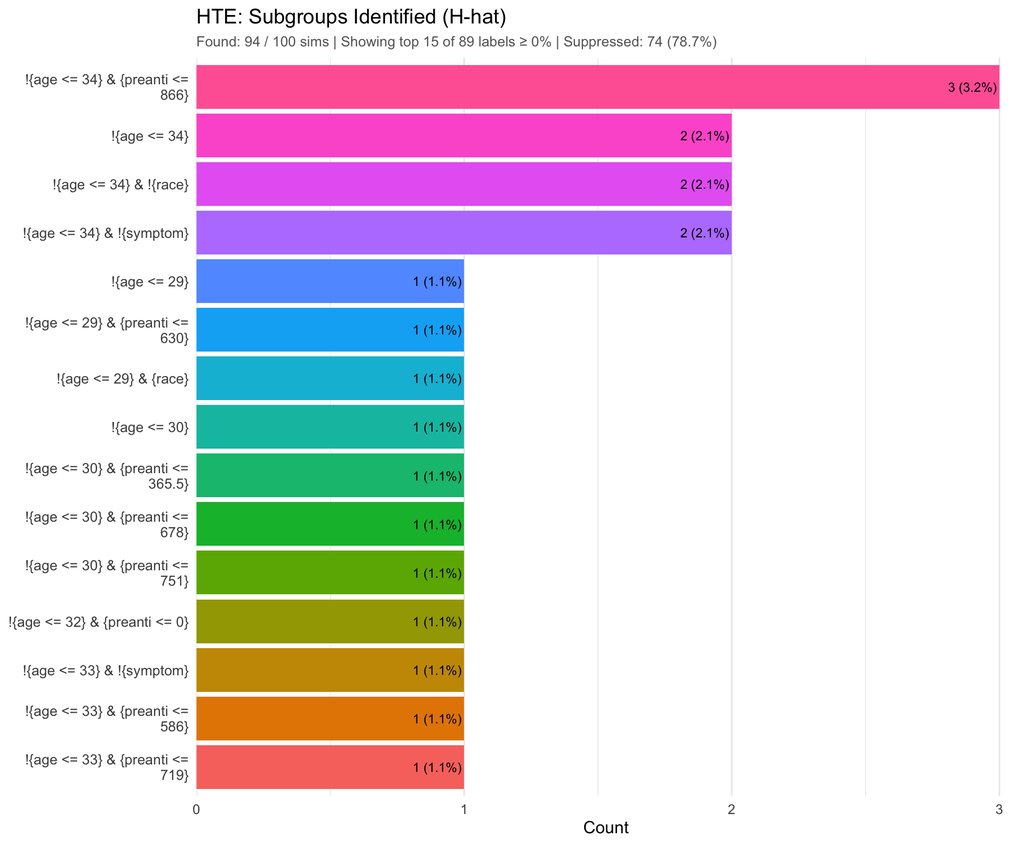

```r
print(plot_sgdist_alt)
```

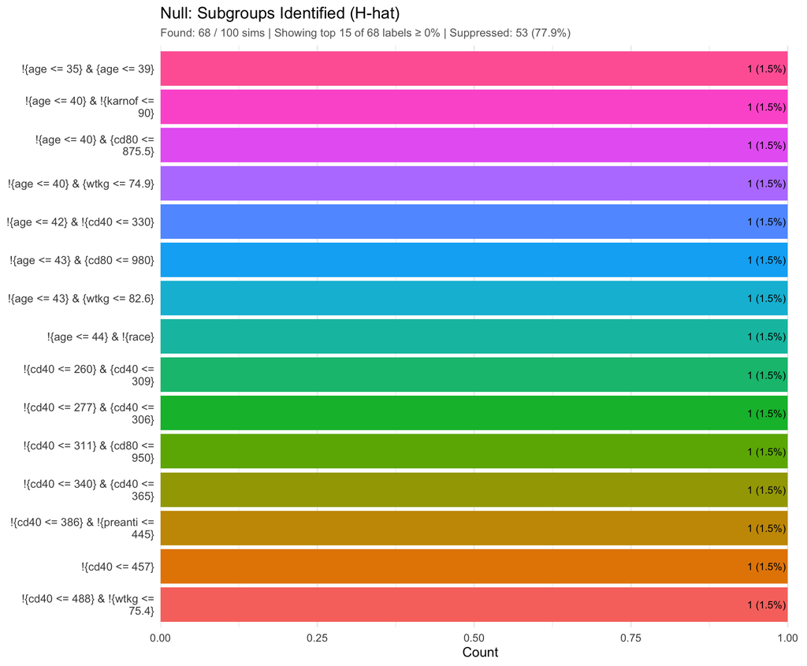

```r
print(plot_sgdist_null)
```

### 8.2.3 Distribution of Effect Estimates

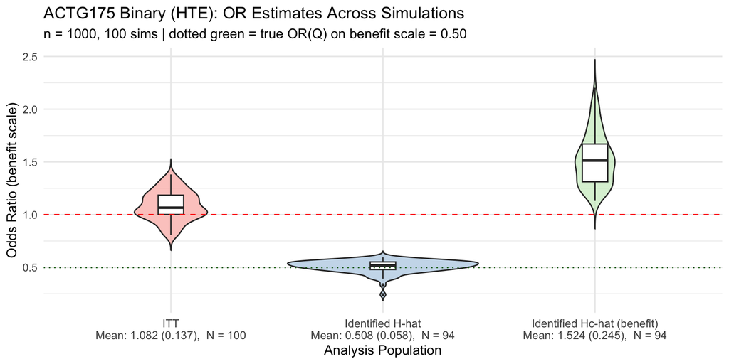

```r
# Invert OR from switched scale to original benefit scale (1/OR).
# Only invert finite positives; leave NAs/non-positives as NA.
invert_or <- function(x) ifelse(is.finite(x) & x > 0, 1 / x, NA_real_)

# Helper: build three-panel OR distribution (ITT, H-hat, Hc-hat).
build_or_panels <- function(results_tbl) {
  fs <- results_tbl[results_tbl$analysis == "FS", ]
  data.table::rbindlist(list(
    data.table::data.table(
      est      = invert_or(fs$hr.itt),
      analysis = "ITT"),
    data.table::data.table(
      est      = invert_or(fs$hr.H.hat[fs$any.H == 1L]),
      analysis = "Identified H-hat"),
    data.table::data.table(
      est      = invert_or(fs$hr.Hc.hat[fs$any.H == 1L]),
      analysis = "Identified Hc-hat (benefit)")
  ))
}

ordist_plot <- function(df_or, title, subtitle,
                         or_ref = NA_real_) {
  df_or$analysis <- factor(
    df_or$analysis,
    levels = c("ITT", "Identified H-hat", "Identified Hc-hat (benefit)"))

  lbls <- vapply(levels(df_or$analysis), function(g) {
    v <- df_or$est[df_or$analysis == g]; v <- v[!is.na(v)]
    if (length(v) < 2) g
    else sprintf("%s\nMean: %.3f (%.3f),  N = %d",
                 g, mean(v), sd(v), length(v))
  }, character(1))

  p <- ggplot2::ggplot(df_or,
                        ggplot2::aes(x = analysis, y = est,
                                     fill = analysis)) +
    ggplot2::geom_violin(trim = FALSE, alpha = 0.7) +
    ggplot2::geom_boxplot(width = 0.12, fill = "white",
                          outlier.size = 0.6) +
    ggplot2::geom_hline(yintercept = 1, colour = "red",
                        linetype = "dashed") +
    ggplot2::scale_x_discrete(labels = lbls) +
    ggplot2::scale_fill_brewer(palette = "Pastel1") +
    ggplot2::labs(x = "Analysis Population",
                  y = "Odds Ratio (benefit scale)",
                  title = title, subtitle = subtitle) +
    ggplot2::theme_minimal(base_size = 12) +
    ggplot2::theme(legend.position = "none",
                   axis.text.x = ggplot2::element_text(size = 10))
  if (!is.na(or_ref)) {
    p <- p + ggplot2::geom_hline(yintercept = or_ref,
                                  colour = "darkgreen",
                                  linetype = "dotted")
  }
  p
}

# H1 panel with OR(Q) truth overlay
or_Q_true <- 1 / dgm_calibrated$hazard_ratios$harm_subgroup
ordist_plot(
  build_or_panels(results_alt),
  title    = "ACTG175 Binary (HTE): OR Estimates Across Simulations",
  subtitle = sprintf(
    "n = %d, %d sims | dotted green = true OR(Q) on benefit scale = %.2f",
    sim_n_sample, nsims_alt, or_Q_true),
  or_ref   = or_Q_true)
```

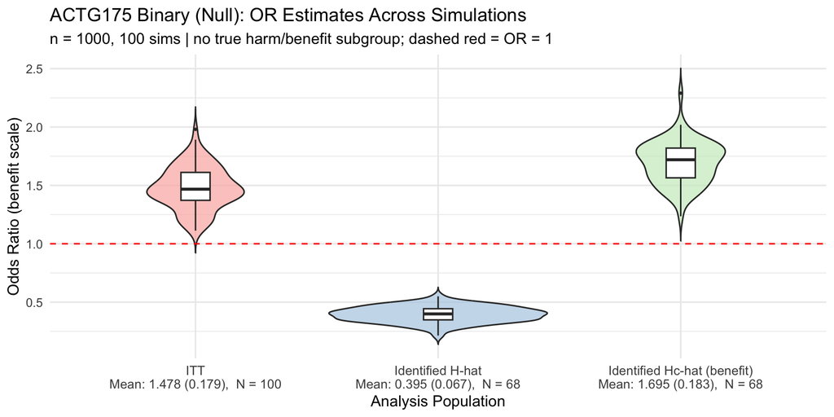

```r
# Under H0, the DGM has no harm subgroup, so there is no OR(Q)
# reference.  Plot with null reference at OR = 1 only.
ordist_plot(
  build_or_panels(results_null),
  title    = "ACTG175 Binary (Null): OR Estimates Across Simulations",
  subtitle = sprintf(
    "n = %d, %d sims | no true harm/benefit subgroup; dashed red = OR = 1",
    sim_n_sample, nsims_null))
```

```r
build_estimation_table(
  results         = results_alt,
  dgm             = dgm_calibrated,
  analysis_method = "FS",
  subtitle = sprintf(
    "ACTG175 Binary DGM (raw cont.) | n = %d, %d sims",
    sim_n_sample, nsims_alt
  ),
  font_size = 16,
  subgroup_notation = sg_notation
)
```

Estimation Properties

ACTG175 Binary DGM (raw cont.) | n = 1000, 100 sims (FS: 94/100 (94%) estimable)

|  | Avg | SD | Min | Max | b† (%) |
| --- | --- | --- | --- | --- | --- |
| Q̂: 94 estimable, avg \|Q̂\| = 356, θ†(Q) = 0.5 |  |  |  |  |  |
| θ̂(Q̂) | 0.51 | 0.06 | 0.24 | 0.6 | 2.01 |
| Q̂ᶜ: avg \|Q̂ᶜ\| = 644, θ†(Qᶜ) = 1.5 |  |  |  |  |  |
| θ̂(Q̂ᶜ) | 1.52 | 0.24 | 1.13 | 2.2 | 1.80 |

θ̂(Q̂) = plugin OR estimate in identified subgroup; θ̂*(Q̂) = bootstrap bias-corrected; b† = bias relative to true OR θ† (causal truth)

```r
if ("GRF" %in% unique(results_alt$analysis)) {
  build_estimation_table(
    results         = results_alt,
    dgm             = dgm_calibrated,
    analysis_method = "GRF",
    subtitle = sprintf(
      "ACTG175 Binary DGM, GRF raw cont. (dmin=%.2f) | n = %d, %d sims",
      grf_dmin, sim_n_sample, nsims_alt
    ),
    font_size = 16,
    subgroup_notation = sg_notation
  )
}
```

Estimation Properties

ACTG175 Binary DGM, GRF raw cont. (dmin=0.10) | n = 1000, 100 sims (GRF: 94/100 (94%) estimable)

|  | Avg | SD | Min | Max | b† (%) |
| --- | --- | --- | --- | --- | --- |
| Q̂: 94 estimable, avg \|Q̂\| = 443, θ†(Q) = 0.5 |  |  |  |  |  |
| θ̂(Q̂) | 0.49 | 0.08 | 0.30 | 0.64 | -1.79 |
| Q̂ᶜ: avg \|Q̂ᶜ\| = 557, θ†(Qᶜ) = 1.5 |  |  |  |  |  |
| θ̂(Q̂ᶜ) | 1.95 | 0.27 | 1.31 | 3.11 | 30.07 |

θ̂(Q̂) = plugin OR estimate in identified subgroup; θ̂*(Q̂) = bootstrap bias-corrected; b† = bias relative to true OR θ† (causal truth)

```r
timings$report_alt <- proc.time()[3] - t0
```

### 8.2.4 Interpretation

```r
interpret_estimation_table(
  results_alt, dgm_calibrated,
  analysis_method = "FS",
  scenario = "alt",
  subgroup_notation = sg_notation
)
```

Under the alternative hypothesis (true OR(Q) = 0.5, true OR(Qc) = 1.5), 94 of 100 simulations (94.0%) identified a subgroup using FS. The identified subgroup averaged 356 patients (complement: 644).

The naive OR in the identified subgroup averaged 0.51 (SD = 0.06), corresponding to 2.0% relative bias versus the true OR(Q) = 0.5. In the complement, the estimate averaged 1.52 (1.8% bias vs. true OR(Qc) = 1.5).

## 8.3 Operating Characteristics Under H0

```r
format_oc_results(
  results_null,
  metrics  = c("detection", "classification"),
  digits   = 2,
  title    = "ACTG175 Binary: Type I Error (Null, Raw Continuous)",
  subtitle = sprintf(
    "n = %d, %d sims, OR(ITT) = %.2f (switched)",
    sim_n_sample, nsims_null,
    dgm_null$hazard_ratios$overall
  ),
  subgroup_notation = sg_notation
)
```

ACTG175 Binary: Type I Error (Null, Raw Continuous)

n = 1000, 100 sims, OR(ITT) = 0.67 (switched)

| Method | Sims | Found | Classification Sen | Classification Spec | Classification PPV | Classification NPV |
| --- | --- | --- | --- | --- | --- | --- |
| FS | 100 | 0.68 | - | 0.92 | 0.00 | 1.00 |
| GRF | 100 | 0.96 | - | 0.82 | 0.00 | 1.00 |

**Note**

Under H0, $Q = \emptyset$. Sen is undefined (shown as “—”) and PPV $\equiv 0$ (León et al. 2024, Section 3). The detection rate (Found) is the false positive rate.

## 8.4 Classification Table

```r
build_classification_table(
  scenario_results = list(
    null = list(
      results  = results_null,
      label    = "ACTG-bin-raw",
      n_sample = sim_n_sample,
      dgm      = dgm_null,
      hypothesis = "null"
    ),
    alt = list(
      results  = results_alt,
      label    = "ACTG-bin-raw",
      n_sample = sim_n_sample,
      dgm      = dgm_calibrated,
      hypothesis = "alt"
    )
  ),
  analyses = sort(unique(c(
    unique(results_null$analysis),
    unique(results_alt$analysis)
  ))),
  digits    = 2,
  font_size = 16,
  title     = "ACTG175 Binary (Raw Continuous): Subgroup Identification and Classification",
  n_sims    = nsims_alt,
  subgroup_notation = sg_notation
)
```

ACTG175 Binary (Raw Continuous): Subgroup Identification and Classification

Across 100 simulations per scenario

|  | FS | GRF |
| --- | --- | --- |
| ACTG-bin-raw Null: N=1000, theta(ITT) = 1.5 |  |  |
| any(Q) | 0.68 | 0.96 |
| sens(Qc) | 0.92 | 0.82 |
| ppv(Qc) | 1.00 | 1.00 |
| avg\|Q\| | 117.00 | 185.00 |
| ACTG-bin-raw Alt: N=1000, p_Q=34%, theta(Q)=0.5, theta(Qc)=1.5, theta(ITT)=1.09 |  |  |
| any(Q) | 0.94 | 0.94 |
| sens(Q) | 0.69 | 0.72 |
| sens(Qc) | 0.84 | 0.72 |
| ppv(Q) | 0.68 | 0.57 |
| ppv(Qc) | 0.88 | 0.87 |
| avg\|Q\| | 356.00 | 443.00 |

# 9 Timing Summary

```r
timings$total <- (proc.time() - t_vignette_start)["elapsed"]

timing_df <- data.frame(
  Step = c(names(timings)),
  Seconds = round(unlist(timings), 1),
  Minutes = round(unlist(timings) / 60, 2)
)

timing_df |>
  gt::gt() |>
  gt::tab_header(title = "Computation Timing") |>
  gt::tab_style(
    style = gt::cell_text(weight = "bold"),
    locations = gt::cells_body(rows = Step == "total")
  )
```

Computation Timing

| Step | Seconds | Minutes |
| --- | --- | --- |
| data_prep | 0.0 | 0.00 |
| dgm_init | 0.0 | 0.00 |
| calibrate | 0.6 | 0.01 |
| dgm_null | 0.0 | 0.00 |
| single_data | 2.6 | 0.04 |
| single_trial | 4.4 | 0.07 |
| sims_alt | 74.8 | 1.25 |
| sims_null | 73.9 | 1.23 |
| report_alt | 1.7 | 0.03 |
| total | 191.1 | 3.19 |

### 9.0.1 Projection for Production Runs

**Projection arithmetic (click to expand)**

```r
# Per-replicate cost (simulation loop only)
time_per_alt  <- timings$sims_alt / nsims_alt
time_per_null <- timings$sims_null / nsims_null

# prod_alt and prod_null defined in setup chunk
proj_alt  <- time_per_alt * prod_alt
proj_null <- time_per_null * prod_null
proj_other <- timings$total - timings$sims_alt - timings$sims_null
proj_total <- proj_alt + proj_null + proj_other

proj_df <- data.frame(
  Metric = c(
    sprintf("Current run (%d alt + %d null on %d workers)",
            nsims_alt, nsims_null, n_workers),
    "Per-replicate, H1",
    "Per-replicate, H0",
    sprintf("Projected H1 (%d sims)", prod_alt),
    sprintf("Projected H0 (%d sims)", prod_null),
    "Projected other (calibration, setup, reporting)",
    "Projected total"),
  Seconds = c(NA_real_,
              time_per_alt, time_per_null,
              proj_alt, proj_null, proj_other, proj_total),
  Minutes = c(NA_real_,
              time_per_alt / 60, time_per_null / 60,
              proj_alt / 60, proj_null / 60, proj_other / 60,
              proj_total / 60),
  Hours   = c(NA_real_, NA_real_, NA_real_, NA_real_, NA_real_,
              NA_real_, proj_total / 3600),
  stringsAsFactors = FALSE)

cat(gt::as_raw_html(
  gt::gt(proj_df) |>
    gt::tab_header(title = sprintf(
      "Projected runtime for production simulation (%d H1 + %d H0)",
      prod_alt, prod_null)) |>
    gt::fmt_number(columns = c("Seconds", "Minutes", "Hours"),
                   decimals = 1) |>
    gt::sub_missing(missing_text = "\u2014") |>
    gt::cols_label(Metric  = gt::md("**Metric**"),
                   Seconds = gt::md("**Seconds**"),
                   Minutes = gt::md("**Minutes**"),
                   Hours   = gt::md("**Hours**")) |>
    gt::tab_options(table.font.size = 11)
), "\n\n")
```

Projected runtime for production simulation (5000 H1 + 25000 H0)

| **Metric** | **Seconds** | **Minutes** | **Hours** |
| --- | --- | --- | --- |
| Current run (100 alt + 100 null on 13 workers) | — | — | — |
| Per-replicate, H1 | 0.7 | 0.0 | — |
| Per-replicate, H0 | 0.7 | 0.0 | — |
| Projected H1 (5000 sims) | 3,741.3 | 62.4 | — |
| Projected H0 (25000 sims) | 18,465.2 | 307.8 | — |
| Projected other (calibration, setup, reporting) | 42.4 | 0.7 | — |
| Projected total | 22,249.0 | 370.8 | 6.2 |

# 10 Discussion

## 10.1 Key Differences from the Survival Simulation

This document mirrors the structure of `actg175_simulations_benefit.qmd` (survival endpoint) with the following differences:

1. **No censoring**: the binary outcome $I(\text{cd420} > \text{cd40})$ is fully observed, eliminating censoring model complexity.
2. **Package GLM simulation suite**: uses `generate_glm_dgm()`, `calibrate_glm_interaction()`, and `simulate_from_glm_dgm()` instead of `generate_aft_dgm_flex()`, manual grid search, and `simulate_from_dgm()`. `run_simulation_analysis()` dispatches automatically based on the `"glm_dgm"` class.
3. **OR replaces HR**: thresholds and reporting use odds ratios on the switched scale. The `subgroup_notation = "benefit"` inversion applies identically.
4. **No CDE/AHR estimands**: these are survival-specific. The binary DGM stores OR-scale effects in the `hazard_ratios` list for reporting compatibility.
5. **GRF standalone included**: the standalone GRF analysis (`grf.subg.harm.glm`) uses `causal_forest()` for candidate factor screening and policy trees for subgroup identification.

## 10.2 Key Difference from the Prior Discretised Setup

The prior version of this document discretised every continuous covariate into a binary factor (using the same cuts that define the true subgroup $Q$) before the analysis step. That setup implicitly gives the analysis methods knowledge of the true cutpoints. **This document feeds raw continuous covariates (`age`, `preanti`, `wtkg`, `karnof`, `cd40`, `cd80`) to the analysis methods**, so the search methods must discover cuts themselves. The DGM construction is unchanged: the true $Q$ is still $\{\text{age} > 34\} \cap \{\text{preanti} \leq 744.5\}$ and the calibration targets the same OR(Q).

**Expected consequences** relative to the discretised run:

- Lower sensitivity and PPV for both FS and GRF, because discovered cuts will generally differ from the true cuts.
- Similar or slightly higher FPR for GRF, because the policy-tree search space is larger over continuous inputs.
- Detection power depends on how closely the median / GRF-derived cuts align with the true cuts.

## 10.3 Limitations

- The binary DGM is based on a logistic regression fitted to the observed ACTG175 data. The super-population preserves the empirical covariate distribution but assumes the logistic model is correctly specified.
- `k_inter` is a direct additive shift on the log-odds scale for Q members under treatment. Positive values increase the outcome for Q; negative values decrease it.
- `dmin.grf` was calibrated on the discretised setup; a fresh calibration run with raw continuous inputs is recommended before production scaling.

## 10.4 Reloading Saved Results

When `save_results = TRUE`, the simulation bundle is saved as an `.rds` file in the `_data/` directory. The bundle carries every scalar, list, and object the vignette reads downstream of the simulation run, which makes it straightforward to (a) reload for interactive analysis or (b) split this document into a separate “run” script and a “report” document in the future.

```r
bundle <- readRDS(
  "../_data/actg175_binary_benefit_simulations_rawcont_100alts_100nulls.rds"
)

# -- Core results (data.tables) --------------------------------------------
results_alt  <- bundle$results_alt
results_null <- bundle$results_null

# -- DGM objects (class "glm_dgm") -----------------------------------------
dgm_calibrated <- bundle$dgm_calibrated
dgm_null       <- bundle$dgm_null

# -- Restore ALL vignette-scope scalars consumed downstream of the run -----
# (Assigning locally lets Section 8 chunks run unchanged against the
#  reloaded bundle.)
with(bundle$config, {
  sim_n_sample        <<- n_sample
  nsims_alt           <<- nsims_alt
  nsims_null          <<- nsims_null
  n_workers           <<- n_workers
  confounders_analysis<<- confounders_analysis
  sg_notation         <<- sg_notation
  sgdist_min_pct_alt  <<- sgdist_min_pct_alt
  sgdist_min_pct_null <<- sgdist_min_pct_null
  sgdist_top_k        <<- sgdist_top_k
  sgdist_show_other_alt  <<- sgdist_show_other_alt
  sgdist_show_other_null <<- sgdist_show_other_null
  grf_dmin            <<- grf_dmin
  prod_alt            <<- prod_alt
  prod_null           <<- prod_null
})

timings      <- bundle$timings
n_failed_alt <- bundle$n_failed_alt
n_failed_null<- bundle$n_failed_null

# -- True effects (convenience) --------------------------------------------
bundle$true_effects$or_Q     # OR(Q) on switched scale
bundle$true_effects$or_Qc    # OR(Qc)
bundle$true_effects$or_ITT   # OR(ITT)
bundle$true_effects$k_inter  # calibrated interaction shift

# -- FS / GRF parameter lists (passed to run_simulation_analysis) ----------
bundle$fs_params
bundle$grf_params

# -- Provenance ------------------------------------------------------------
bundle$timestamp         # when the run completed
bundle$R_version         # R version used
bundle$fs_version        # forestsearch version used

# -- Reproduce Section 8 tables with the reloaded objects ------------------
format_oc_results(results_alt,    subgroup_notation = sg_notation, ...)
build_estimation_table(results_alt, dgm = dgm_calibrated,
                        subgroup_notation = sg_notation, ...)
```

# 11 Summary

**Compute summary metrics**

```r
mc_se <- function(p, n) sqrt(p * (1 - p) / n)
methods <- sort(unique(results_alt$analysis))

summ <- data.frame(Method = methods, stringsAsFactors = FALSE)
for (m in methods) {
  ra <- results_alt[results_alt$analysis == m, ]
  rn <- results_null[results_null$analysis == m, ]

  summ$alt_det[summ$Method == m]   <- mean(ra$any.H, na.rm = TRUE)
  summ$null_fpr[summ$Method == m]  <- mean(rn$any.H, na.rm = TRUE)
  summ$alt_sens[summ$Method == m]  <- mean(ra$sens, na.rm = TRUE)
  summ$alt_ppv[summ$Method == m]   <- mean(ra$ppv, na.rm = TRUE)
  summ$se_det[summ$Method == m]    <- mc_se(
    summ$alt_det[summ$Method == m], nrow(ra))
  summ$se_fpr[summ$Method == m]    <- mc_se(
    summ$null_fpr[summ$Method == m], nrow(rn))
}
```

## 11.1 FS vs GRF Classification Concordance Across Simulations

Per-subject classification concordance between ForestSearch and GRF is computed within each simulation replicate by `run_simulation_analysis()` and stored as `agree.FS.GRF` and `kappa.FS.GRF` columns. When a method does not detect a subgroup, it classifies all subjects to $Q^c$.

**Classification concordance (click to expand)**

```r
conc_col <- "agree.FS.GRF"
kappa_col <- "kappa.FS.GRF"

if (all(c(conc_col, kappa_col) %in% names(results_alt)) &&
    all(c("FS", "GRF") %in% methods)) {

  # One row per sim (take FS rows — concordance is per-sim, same on both)
  fs_alt  <- results_alt[results_alt$analysis == "FS", ]
  grf_alt <- results_alt[results_alt$analysis == "GRF", ]
  n       <- nrow(fs_alt)

  both     <- sum(fs_alt$any.H == 1 & grf_alt$any.H == 1)
  fs_only  <- sum(fs_alt$any.H == 1 & grf_alt$any.H == 0)
  grf_only <- sum(fs_alt$any.H == 0 & grf_alt$any.H == 1)
  neither  <- sum(fs_alt$any.H == 0 & grf_alt$any.H == 0)
  both_idx <- fs_alt$any.H == 1 & grf_alt$any.H == 1

  conc_df <- data.frame(
    Metric = c(
      "Mean agreement (%)",
      "SD agreement (%)",
      "Mean kappa",
      "SD kappa",
      "Median kappa",
      "Both detect",
      "FS only",
      "GRF only",
      "Neither",
      sprintf("Mean agreement | both detect (n = %d)", both),
      sprintf("Mean kappa | both detect (n = %d)",     both)
    ),
    Value = c(
      sprintf("%.1f", 100 * mean(fs_alt[[conc_col]],  na.rm = TRUE)),
      sprintf("%.1f", 100 * sd(fs_alt[[conc_col]],    na.rm = TRUE)),
      sprintf("%.3f",       mean(fs_alt[[kappa_col]], na.rm = TRUE)),
      sprintf("%.3f",       sd(fs_alt[[kappa_col]],   na.rm = TRUE)),
      sprintf("%.3f",       median(fs_alt[[kappa_col]], na.rm = TRUE)),
      sprintf("%d (%.0f%%)", both,     100 * both     / n),
      sprintf("%d (%.0f%%)", fs_only,  100 * fs_only  / n),
      sprintf("%d (%.0f%%)", grf_only, 100 * grf_only / n),
      sprintf("%d (%.0f%%)", neither,  100 * neither  / n),
      if (both > 0)
        sprintf("%.1f%%", 100 * mean(fs_alt[[conc_col]][both_idx],  na.rm = TRUE))
      else "\u2014",
      if (both > 0)
        sprintf("%.3f",         mean(fs_alt[[kappa_col]][both_idx], na.rm = TRUE))
      else "\u2014"
    ),
    stringsAsFactors = FALSE)

  cat(gt::as_raw_html(
    gt::gt(conc_df,
           groupname_col = NULL) |>
      gt::tab_header(title = sprintf(
        "FS vs GRF classification concordance (%d sims)", n)) |>
      gt::tab_row_group(label = "Overall agreement",
                        rows = 1:5) |>
      gt::tab_row_group(label = "Detection patterns",
                        rows = 6:9) |>
      gt::tab_row_group(label = "Conditional on both detecting",
                        rows = 10:11) |>
      gt::row_group_order(groups = c(
        "Overall agreement",
        "Detection patterns",
        "Conditional on both detecting")) |>
      gt::cols_label(Metric = gt::md("**Metric**"),
                     Value  = gt::md("**Value**")) |>
      gt::tab_options(table.font.size = 11)
  ), "\n\n")

} else {
  cat("*Concordance columns not found in results.  Ensure",
      "`run_simulation_analysis()` was called with",
      "`run_fs = TRUE` and `run_grf = TRUE`.*\n\n")
}
```

FS vs GRF classification concordance (100 sims)

| **Metric** | **Value** |
| --- | --- |
| Overall agreement |  |
| Mean agreement (%) | 78.3 |
| SD agreement (%) | 14.1 |
| Mean kappa | 0.489 |
| SD kappa | 0.324 |
| Median kappa | 0.533 |
| Detection patterns |  |
| Both detect | 88 (88%) |
| FS only | 6 (6%) |
| GRF only | 6 (6%) |
| Neither | 0 (0%) |
| Conditional on both detecting |  |
| Mean agreement \| both detect (n = 88) | 79.0% |
| Mean kappa \| both detect (n = 88) | 0.556 |

## 11.2 Key Findings

**Summary computation (click to expand)**

```r
# Top-line narrative (kept as markdown, not a table)
cat(sprintf(
  "**Simulation budget**: %d H1 + %d H0 sims.\n\n",
  nsims_alt, nsims_null))
```

**Simulation budget**: 100 H1 + 100 H0 sims.

**Summary computation (click to expand)**

```r
cat("**Analysis setting**: raw continuous covariates;",
    "cuts discovered by the methods.\n\n")
```

**Analysis setting**: raw continuous covariates; cuts discovered by the methods.

**Summary computation (click to expand)**

```r
# Per-method operating-characteristic summary as a gt table
truth_label <- ifelse(sg_notation == "benefit", "Q", "H")

kf_df <- data.frame(
  Method         = summ$Method,
  `Detection (%)` = sprintf("%.1f", 100 * summ$alt_det),
  `FPR (%)`       = sprintf("%.1f", 100 * summ$null_fpr),
  `Sens`          = sprintf("%.2f", summ$alt_sens),
  `PPV`           = sprintf("%.2f", summ$alt_ppv),
  check.names = FALSE,
  stringsAsFactors = FALSE)

cat(gt::as_raw_html(
  gt::gt(kf_df) |>
    gt::tab_header(title = "Operating characteristics by method") |>
    gt::tab_spanner(label = sprintf("Classification vs %s", truth_label),
                    columns = c("Sens", "PPV")) |>
    gt::cols_label(Method = gt::md("**Method**")) |>
    gt::tab_options(table.font.size = 11)
), "\n\n")
```

Operating characteristics by method

| **Method** | Detection (%) | FPR (%) | Classification vs Q Sens | Classification vs Q PPV |
| --- | --- | --- | --- | --- |
| FS | 94.0 | 68.0 | 0.69 | 0.68 |
| GRF | 94.0 | 96.0 | 0.72 | 0.57 |

**Summary computation (click to expand)**

```r
# Timing summary as a second compact gt table
time_per_alt  <- timings$sims_alt  / nsims_alt
time_per_null <- timings$sims_null / nsims_null
time_df <- data.frame(
  Metric = c(sprintf("Per-replicate (H1), %d workers",  n_workers),
             sprintf("Per-replicate (H0), %d workers",  n_workers),
             "This run (total)",
             sprintf("Projected production (%d H1 + %d H0)",
                     prod_alt, prod_null)),
  Value  = c(sprintf("%.1f sec",  time_per_alt),
             sprintf("%.1f sec",  time_per_null),
             sprintf("%.1f min",  as.numeric(timings$total) / 60),
             sprintf("%.1f hours",
                     (prod_alt  * time_per_alt +
                      prod_null * time_per_null) / 3600)),
  stringsAsFactors = FALSE)

cat(gt::as_raw_html(
  gt::gt(time_df) |>
    gt::tab_header(title = "Timing") |>
    gt::cols_label(Metric = gt::md("**Metric**"),
                   Value  = gt::md("**Value**")) |>
    gt::tab_options(table.font.size = 11)
), "\n\n")
```

Timing

| **Metric** | **Value** |
| --- | --- |
| Per-replicate (H1), 13 workers | 0.7 sec |
| Per-replicate (H0), 13 workers | 0.7 sec |
| This run (total) | 3.2 min |
| Projected production (5000 H1 + 25000 H0) | 6.2 hours |

# 13 References

- Hammer, S.M., et al. (1996). *NEJM*, 335, 1081–1090.
- Leon, L.F., et al. (2024). *Statistics in Medicine*, 43, 3921–3942.
- Tsiatis, A.A., et al. (2008). *Statistics in Medicine*, 27, 4658–4677.